# Tarea 1: caja de herramientas de pronóstico

Autor/a

Juan David Garro

Fecha de publicación

21 de septiembre de 2026

# 1 Propósito y forma de ejecución

Este informe documenta ocho métodos de pronóstico implementados manualmente en R. Para cada ejemplo se conserva el mismo orden: descripción verificable de la serie, gráfica y correlograma antes del ajuste, lectura del patrón, partición temporal, ajuste, comparación con el referente ingenuo, validación de errores, conclusión y recomendación.

La ejecución oficial desde la raíz del repositorio es:

```r
source("ejemplos/ejemplos.R")
```

```powershell
& "C:\Program Files\RStudio\resources\app\bin\quarto\bin\quarto.exe" render informe/informe.qmd --to html
```

El primer comando genera las figuras y los objetos numéricos. El segundo transforma este archivo QMD en el informe HTML. Los parámetros se eligen únicamente con el tramo de estimación; las observaciones de validación no intervienen en la selección.

# 2 Convenciones estadísticas

La ACF muestral se calcula manualmente con divisor único $T$. Para cada rezago se usa la banda

$$\pm \frac{z_{0.975}}{\sqrt{n}},$$

con $n$ igual al número de observaciones de la sucesión graficada. Ljung–Box se calcula como

$$Q_m=T(T+2)\sum_{h=1}^{m}\frac{r_h^2}{T-h}$$

y se compara con $\chi^2_{m-p}$ en los errores. La partición reserva las últimas $h=\min\{12,\lfloor0.2T\rfloor\}$ observaciones y, en una serie estacional, por lo menos un ciclo completo. MASE utiliza como escala el error absoluto medio del ingenuo correspondiente dentro del tramo de estimación.

# 3 Resumen de los ocho ejemplos

```r
resumen_visible <- resumen[c("metodo", "serie", "parametros", "h", "referente",
                             "MASE_metodo", "MASE_referencia", "p_LB_errores")]
names(resumen_visible) <- c("Método", "Serie", "Parámetros", "h", "Referente",
                             "MASE método", "MASE referente", "p Ljung–Box errores")
tabla_md(resumen_visible, 4L)
```

| Método | Serie | Parámetros | h | Referente | MASE método | MASE referente | p Ljung–Box errores |
| --- | --- | --- | --- | --- | --- | --- | --- |
| Media recursiva | discoveries | media=3.31 | 12.0000 | Ingenuo | 0.9192 | 1.1365 | 0.1181 |
| Media móvil | Nile | k=9 | 12.0000 | Ingenuo | 0.8251 | 0.8355 | 0.0036 |
| SES | LakeHuron | alpha=0.98 | 12.0000 | Ingenuo | 2.1413 | 2.1642 | 0.1188 |
| Doble media móvil | WWWusage | k=2 | 12.0000 | Ingenuo | 1.3676 | 7.6247 | 1.17e-06 |
| Tendencia lineal | austres | lineal; R2=0.993 | 12.0000 | Ingenuo estacional | 1.0017 | 1.9903 | 3.78e-103 |
| Tendencia cuadrática | airmiles | cuadratica; R2=0.989 | 4.0000 | Ingenuo | 1.2055 | 4.4959 | 3.01e-04 |
| Tendencia exponencial | JohnsonJohnson | exponencial; R2=0.973 | 12.0000 | Ingenuo estacional | 3.5860 | 6.5286 | 5.12e-15 |
| Holt | LakeHuron | alpha=0.95; beta=0.05 | 12.0000 | Ingenuo | 2.0902 | 2.1642 | 0.0636 |

# 4 Ejemplos

## 4.1 Media recursiva sobre `discoveries`

### 4.1.1 Serie y patrón antes del ajuste

```r
x <- resultados[[1]]
mostrar_serie(x)
```

| Campo | Valor |
| --- | --- |
| Objeto de R | discoveries |
| Fuente documentada en help() | The World Almanac and Book of Facts, edición de 1975, pp. 315–318. |
| Unidad | número de descubrimientos |
| Frecuencia | 1 |
| Rango | 1860-01-01 a 1959-01-01 |
| Observaciones | 100 |

**Contrastes individuales de la ACF.** Bajo H0: ρ_h = 0, se compara cada r_h con la banda ±0.209. Quedan fuera de la banda: h=1 (r=0.231); h=2 (r=0.209); h=21 (r=-0.219). Estos contrastes son descriptivos e individuales; no sustituyen la prueba conjunta de Ljung–Box.

**Lectura previa del patrón.** La serie fluctúa alrededor de un nivel sin una tendencia sostenida. La ausencia de autocorrelaciones individuales dominantes favorece usar la media histórica como referencia de nivel.

#### 4.1.1.1 Ljung–Box sobre la serie

1. **Hipótesis:**

$$\begin{aligned}
H_0 &: \rho_1 = \rho_2 = \cdots = \rho_m = 0, \\
H_1 &: \exists\,h \in \{1,\ldots,m\}: \rho_h \neq 0.
\end{aligned}$$

2. **Estadístico y distribución bajo H₀:**

$$\begin{aligned}
Q_m &= T(T+2) \sum_{h=1}^{m} \frac{r_h^2}{T-h}, \\[4pt]
Q_m \mid H_0 &\approx \chi^2_{22}.
\end{aligned}$$

3. **Región de rechazo con α = 0.05:**

$$Q_m > \chi^2_{0.95;22} = 33.9244$$

4. **Valor observado y valor p:**

$$Q_{m,\mathrm{obs}} = 31.4223, \qquad p = 0.0878$$

5. **Decisión:** No se rechaza H0 al nivel del 5 %.
6. **Lectura en contexto:** No se detecta dependencia conjunta al 5 %; el gráfico sigue siendo necesario para valorar nivel, tendencia y posibles ciclos.

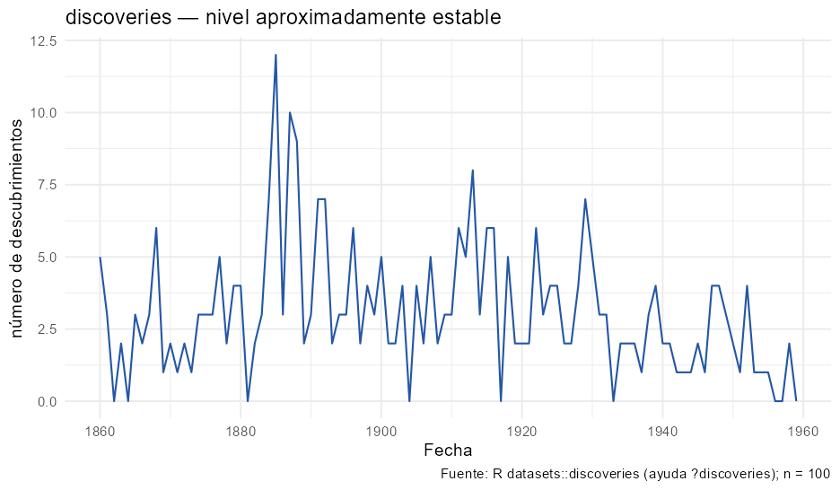

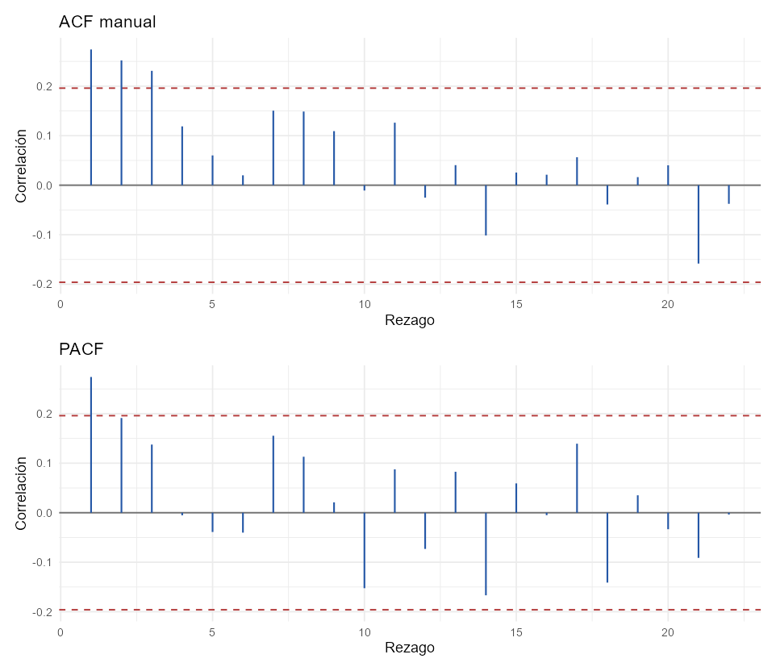

### 4.1.2 Ajuste, validación y referente

```r
mostrar_ajuste(x)
```

El tramo de estimación contiene **88 observaciones** y la validación conserva las últimas **12 observaciones**. El ajuste seleccionado es **media=3.31**.

Este método no requiere seleccionar parámetros mediante una rejilla; sus parámetros se estiman directamente con el tramo de estimación.

| Muestra | MSE | MAD | MAPE | MASE |
| --- | --- | --- | --- | --- |
| Estimación: pronóstico de un paso | 5.4246 | 1.7663 | NA | 0.8306 |
| Validación: método | 4.8801 | 1.9545 | NA | 0.9192 |
| Validación: Ingenuo | 7.7500 | 2.4167 | NA | 1.1365 |

Con el mismo origen y horizonte, el método sí supera al referente según MASE: 0.919 frente a 1.136.

### 4.1.3 Validación de los errores

```r
mostrar_diagnosticos(x)
```

Los diagnósticos utilizan **87 errores efectivos** después de retirar las posiciones de calentamiento.

#### 4.1.3.1 Media cero de los errores

1. **Hipótesis:**

$$\begin{aligned}
H_0 &: \mu_e = 0, \\
H_1 &: \mu_e \neq 0.
\end{aligned}$$

2. **Estadístico y distribución bajo H₀:**

$$\begin{aligned}
t &= \frac{\bar e}{s_e/\sqrt{n_e}}, \\[4pt]
t \mid H_0 &\sim t_{86}.
\end{aligned}$$

3. **Región de rechazo con α = 0.05:**

$$|t| > t_{0.975;86} = 1.9879$$

4. **Valor observado y valor p:**

$$t_{\mathrm{obs}} = 0.1943, \qquad p = 0.8464$$

5. **Decisión:** No se rechaza H0 al nivel del 5 %.
6. **Lectura en contexto:** No se detecta sesgo medio en los errores al 5 %.

#### 4.1.3.2 Ljung–Box sobre los errores

1. **Hipótesis:**

$$\begin{aligned}
H_0 &: \rho_1 = \rho_2 = \cdots = \rho_m = 0, \\
H_1 &: \exists\,h \in \{1,\ldots,m\}: \rho_h \neq 0.
\end{aligned}$$

2. **Estadístico y distribución bajo H₀:**

$$\begin{aligned}
Q_m &= T_e(T_e+2) \sum_{h=1}^{m} \frac{r_h^2}{T_e-h}, \\[4pt]
Q_m \mid H_0 &\approx \chi^2_{m-p} = \chi^2_{20}.
\end{aligned}$$

3. **Región de rechazo con α = 0.05:**

$$Q_m > \chi^2_{0.95;20} = 31.4104$$

4. **Valor observado y valor p:**

$$Q_{m,\mathrm{obs}} = 27.6425, \qquad p = 0.1181$$

5. **Decisión:** No se rechaza H0 al nivel del 5 %.
6. **Lectura en contexto:** No se detecta autocorrelación conjunta residual al 5 %.

#### 4.1.3.3 Jarque–Bera

1. **Hipótesis:**

$$\begin{aligned}
H_0 &: A = 0 \text{ y } K = 3, \\
H_1 &: A \neq 0 \text{ o } K \neq 3.
\end{aligned}$$

2. **Estadístico y distribución bajo H₀:**

$$\begin{aligned}
JB &= \frac{n}{6}\left[A^2 + \frac{(K-3)^2}{4}\right], \\[4pt]
JB \mid H_0 &\approx \chi^2_2.
\end{aligned}$$

3. **Región de rechazo con α = 0.05:**

$$JB > \chi^2_{0.95;2} = 5.9915$$

4. **Valor observado y valor p:**

$$JB_{\mathrm{obs}} = 41.2674, \qquad p = 1.09 \times 10^{-9}$$

5. **Decisión:** Se rechaza H0 al nivel del 5 %.
6. **Lectura en contexto:** Los errores no son compatibles con normalidad aproximada según asimetría y curtosis.

#### 4.1.3.4 Durbin–Watson

1. **Hipótesis:**

$$\begin{aligned}
H_0 &: \rho_1 = 0, \\
H_1 &: \rho_1 > 0.
\end{aligned}$$

2. **Estadístico y referencia:**

$$\begin{aligned}
d &= \frac{\sum_{t=2}^{n_e}(e_t-e_{t-1})^2}{\sum_{t=1}^{n_e}e_t^2}, \\[4pt]
d_L, d_U &\text{ dependen de } n_e \text{ y del número de regresores}.
\end{aligned}$$

3. **Región de decisión con α = 0.05:**

$$\begin{cases} d<d_L &\Rightarrow \text{ rechazar } H_0, \\[2pt] d>d_U &\Rightarrow \text{ no rechazar } H_0, \\[2pt] d_L\le d\le d_U &\Rightarrow \text{ resultado inconcluso}. \end{cases}$$

4. **Valor observado:**

$$d_{\mathrm{obs}} = 1.5043, \qquad p = \mathrm{NA}$$

5. **Decisión:** no se calcula una decisión formal; este método no tiene una matriz de diseño fija (no es una regresión), y la rúbrica exige las cotas $d_L$/$d_U$ únicamente para los tres ejemplos de tendencia.
6. **Lectura en contexto:** valores muy inferiores a 2 son compatibles descriptivamente con autocorrelación positiva, pero no sustituyen una decisión formal.

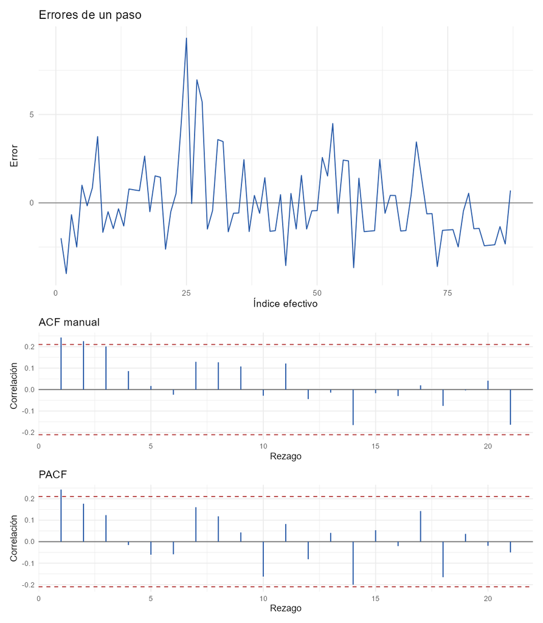

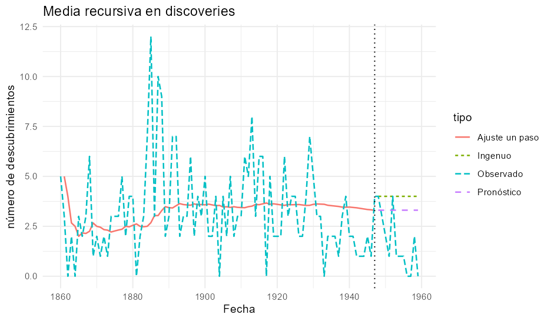

### 4.1.4 Conclusión y recomendación

```r
cierre_md(x)
```

**Conclusión.** Se ajustó Media recursiva con media=3.31. En las 12 observaciones de validación obtuvo MSE = 4.880, MAD = 1.955, MAPE = NA y MASE = 0.919. El referente ingenuo produjo MASE = 1.136. En los errores, Ljung–Box dio p = 0.1181 y la prueba de media cero dio p = 0.8464.

**Recomendación.** El resultado podría servir a una persona que necesite un nivel base anual de actividad científica solamente hasta un horizonte de 12 años. Su límite principal es que la media global no representa ciclos ni cambios persistentes de nivel; esto se evidencia con MASE = 0.919 y p de Ljung–Box residual = 0.1181.

## 4.2 Media móvil sobre `Nile`

### 4.2.1 Serie y patrón antes del ajuste

```r
x <- resultados[[2]]
mostrar_serie(x)
```

| Campo | Valor |
| --- | --- |
| Objeto de R | Nile |
| Fuente documentada en help() | Durbin y Koopman (2001), Time Series Analysis by State Space Methods, Oxford University Press. |
| Unidad | caudal anual (10^8 m³) |
| Frecuencia | 1 |
| Rango | 1871-01-01 a 1970-01-01 |
| Observaciones | 100 |

**Contrastes individuales de la ACF.** Bajo H0: ρ_h = 0, se compara cada r_h con la banda ±0.209. Quedan fuera de la banda: h=1 (r=0.521); h=2 (r=0.410); h=3 (r=0.325); h=4 (r=0.285); h=5 (r=0.263); h=6 (r=0.264); h=7 (r=0.260); h=8 (r=0.321); h=11 (r=0.237); h=12 (r=0.256); h=13 (r=0.265); h=14 (r=0.230). Estos contrastes son descriptivos e individuales; no sustituyen la prueba conjunta de Ljung–Box.

**Lectura previa del patrón.** La serie presenta cambios lentos de nivel y dependencia temporal. Una ventana móvil puede adaptarse al nivel reciente mejor que una media calculada con toda la historia.

#### 4.2.1.1 Ljung–Box sobre la serie

1. **Hipótesis:**

$$\begin{aligned}
H_0 &: \rho_1 = \rho_2 = \cdots = \rho_m = 0, \\
H_1 &: \exists\,h \in \{1,\ldots,m\}: \rho_h \neq 0.
\end{aligned}$$

2. **Estadístico y distribución bajo H₀:**

$$\begin{aligned}
Q_m &= T(T+2) \sum_{h=1}^{m} \frac{r_h^2}{T-h}, \\[4pt]
Q_m \mid H_0 &\approx \chi^2_{22}.
\end{aligned}$$

3. **Región de rechazo con α = 0.05:**

$$Q_m > \chi^2_{0.95;22} = 33.9244$$

4. **Valor observado y valor p:**

$$Q_{m,\mathrm{obs}} = 136.2169, \qquad p = 1.82 \times 10^{-18}$$

5. **Decisión:** Se rechaza H0 al nivel del 5 %.
6. **Lectura en contexto:** La serie no se comporta como ruido blanco: existe dependencia conjunta antes de ajustar el método.

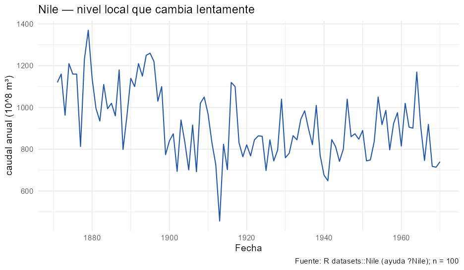

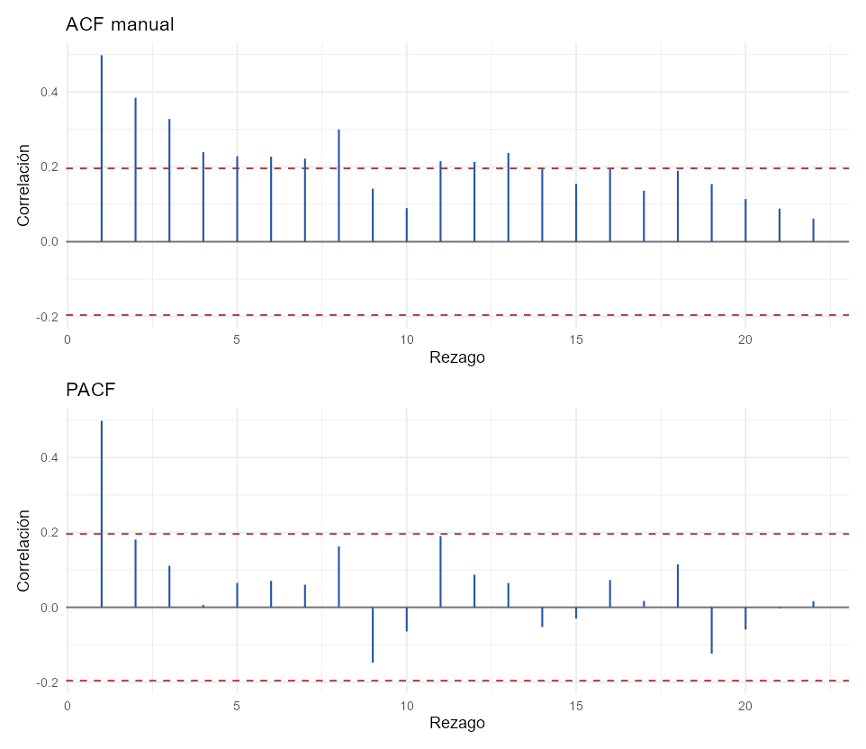

### 4.2.2 Selección de ventana, ajuste y validación

```r
mostrar_ajuste(x)
```

El tramo de estimación contiene **88 observaciones** y la validación conserva las últimas **12 observaciones**. El ajuste seleccionado es **k=9**.

El óptimo se encuentra en el interior de la rejilla evaluada.

| Muestra | MSE | MAD | MAPE | MASE |
| --- | --- | --- | --- | --- |
| Estimación: pronóstico de un paso | 22175.0924 | 114.9086 | 13.5438 | 0.8649 |
| Validación: método | 17660.6049 | 109.6296 | 12.6691 | 0.8251 |
| Validación: Ingenuo | 19685.0000 | 111.0000 | 13.4537 | 0.8355 |

Con el mismo origen y horizonte, el método sí supera al referente según MASE: 0.825 frente a 0.835.

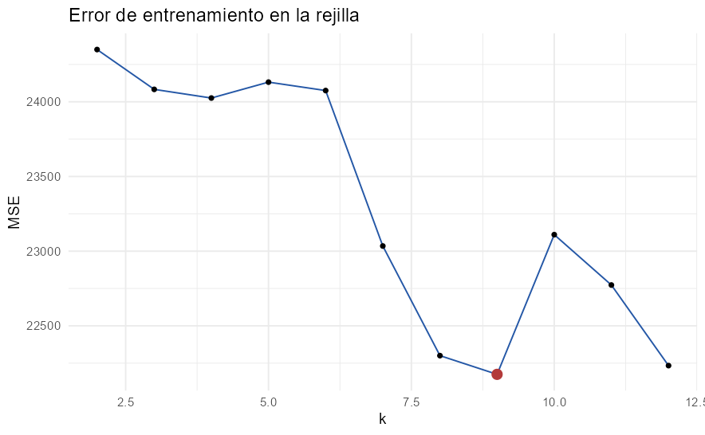

```r
figuras_md(x$figuras["optimizacion"])
```

### 4.2.3 Validación de los errores

```r
mostrar_diagnosticos(x)
```

Los diagnósticos utilizan **79 errores efectivos** después de retirar las posiciones de calentamiento.

#### 4.2.3.1 Media cero de los errores

1. **Hipótesis:**

$$\begin{aligned}
H_0 &: \mu_e = 0, \\
H_1 &: \mu_e \neq 0.
\end{aligned}$$

2. **Estadístico y distribución bajo H₀:**

$$\begin{aligned}
t &= \frac{\bar e}{s_e/\sqrt{n_e}}, \\[4pt]
t \mid H_0 &\sim t_{78}.
\end{aligned}$$

3. **Región de rechazo con α = 0.05:**

$$|t| > t_{0.975;78} = 1.9908$$

4. **Valor observado y valor p:**

$$t_{\mathrm{obs}} = -0.9624, \qquad p = 0.3388$$

5. **Decisión:** No se rechaza H0 al nivel del 5 %.
6. **Lectura en contexto:** No se detecta sesgo medio en los errores al 5 %.

#### 4.2.3.2 Ljung–Box sobre los errores

1. **Hipótesis:**

$$\begin{aligned}
H_0 &: \rho_1 = \rho_2 = \cdots = \rho_m = 0, \\
H_1 &: \exists\,h \in \{1,\ldots,m\}: \rho_h \neq 0.
\end{aligned}$$

2. **Estadístico y distribución bajo H₀:**

$$\begin{aligned}
Q_m &= T_e(T_e+2) \sum_{h=1}^{m} \frac{r_h^2}{T_e-h}, \\[4pt]
Q_m \mid H_0 &\approx \chi^2_{m-p} = \chi^2_{18}.
\end{aligned}$$

3. **Región de rechazo con α = 0.05:**

$$Q_m > \chi^2_{0.95;18} = 28.8693$$

4. **Valor observado y valor p:**

$$Q_{m,\mathrm{obs}} = 38.2646, \qquad p = 0.0036$$

5. **Decisión:** Se rechaza H0 al nivel del 5 %.
6. **Lectura en contexto:** Permanece autocorrelación aprovechable: el método no extrajo toda la estructura temporal.

#### 4.2.3.3 Jarque–Bera

1. **Hipótesis:**

$$\begin{aligned}
H_0 &: A = 0 \text{ y } K = 3, \\
H_1 &: A \neq 0 \text{ o } K \neq 3.
\end{aligned}$$

2. **Estadístico y distribución bajo H₀:**

$$\begin{aligned}
JB &= \frac{n}{6}\left[A^2 + \frac{(K-3)^2}{4}\right], \\[4pt]
JB \mid H_0 &\approx \chi^2_2.
\end{aligned}$$

3. **Región de rechazo con α = 0.05:**

$$JB > \chi^2_{0.95;2} = 5.9915$$

4. **Valor observado y valor p:**

$$JB_{\mathrm{obs}} = 1.0738, \qquad p = 0.5845$$

5. **Decisión:** No se rechaza H0 al nivel del 5 %.
6. **Lectura en contexto:** No se rechaza la compatibilidad aproximada con normalidad.

#### 4.2.3.4 Durbin–Watson

1. **Hipótesis:**

$$\begin{aligned}
H_0 &: \rho_1 = 0, \\
H_1 &: \rho_1 > 0.
\end{aligned}$$

2. **Estadístico y referencia:**

$$\begin{aligned}
d &= \frac{\sum_{t=2}^{n_e}(e_t-e_{t-1})^2}{\sum_{t=1}^{n_e}e_t^2}, \\[4pt]
d_L, d_U &\text{ dependen de } n_e \text{ y del número de regresores}.
\end{aligned}$$

3. **Región de decisión con α = 0.05:**

$$\begin{cases} d<d_L &\Rightarrow \text{ rechazar } H_0, \\[2pt] d>d_U &\Rightarrow \text{ no rechazar } H_0, \\[2pt] d_L\le d\le d_U &\Rightarrow \text{ resultado inconcluso}. \end{cases}$$

4. **Valor observado:**

$$d_{\mathrm{obs}} = 1.2661, \qquad p = \mathrm{NA}$$

5. **Decisión:** no se calcula una decisión formal; este método no tiene una matriz de diseño fija (no es una regresión), y la rúbrica exige las cotas $d_L$/$d_U$ únicamente para los tres ejemplos de tendencia.
6. **Lectura en contexto:** valores muy inferiores a 2 son compatibles descriptivamente con autocorrelación positiva, pero no sustituyen una decisión formal.

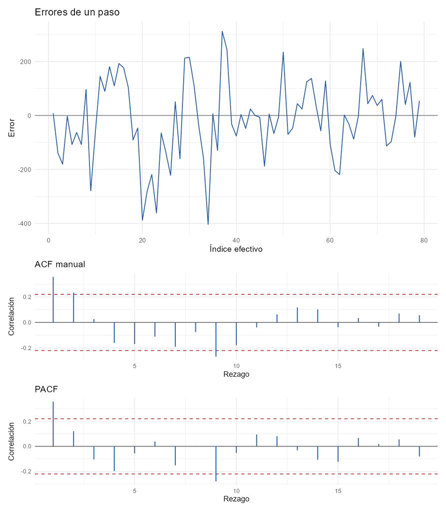

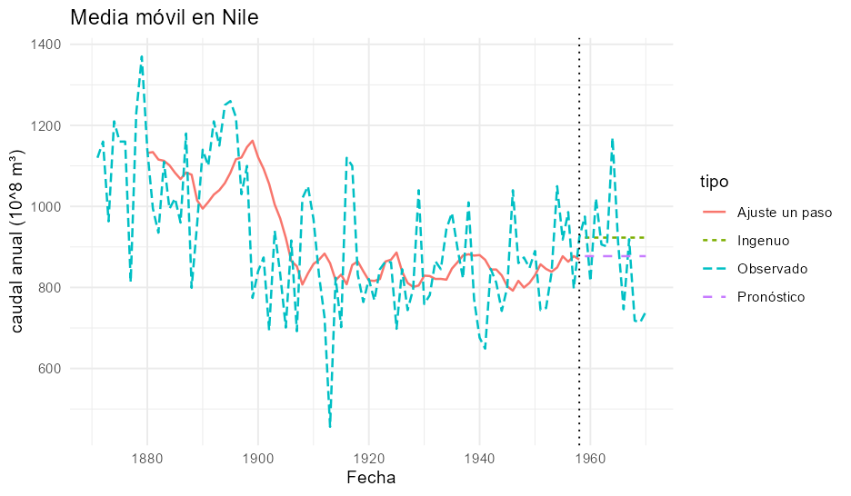

### 4.2.4 Conclusión y recomendación

```r
cierre_md(x)
```

**Conclusión.** Se ajustó Media móvil con k=9. En las 12 observaciones de validación obtuvo MSE = 17660.605, MAD = 109.630, MAPE = 12.669 y MASE = 0.825. El referente ingenuo produjo MASE = 0.835. En los errores, Ljung–Box dio p = 0.0036 y la prueba de media cero dio p = 0.3388.

**Recomendación.** El resultado podría servir a un analista de caudal que requiera un nivel reciente suavizado solamente hasta un horizonte de 12 años. Su límite principal es que la ventana móvil deja dependencia en los errores; esto se evidencia con MASE = 0.825 y p de Ljung–Box residual = 0.0036.

## 4.3 Suavizamiento exponencial simple sobre `LakeHuron`

### 4.3.1 Serie y patrón antes del ajuste

```r
x <- resultados[[3]]
mostrar_serie(x)
```

| Campo | Valor |
| --- | --- |
| Objeto de R | LakeHuron |
| Fuente documentada en help() | Brockwell y Davis (1991), Time Series and Forecasting Methods, serie A, p. 555; y Brockwell y Davis (1996), secciones 5.1 y 7.6. |
| Unidad | nivel en pies |
| Frecuencia | 1 |
| Rango | 1875-01-01 a 1972-01-01 |
| Observaciones | 98 |

**Contrastes individuales de la ACF.** Bajo H0: ρ_h = 0, se compara cada r_h con la banda ±0.211. Quedan fuera de la banda: h=1 (r=0.829); h=2 (r=0.595); h=3 (r=0.447); h=4 (r=0.370); h=5 (r=0.322); h=6 (r=0.290); h=7 (r=0.297); h=8 (r=0.335); h=9 (r=0.353); h=10 (r=0.301); h=11 (r=0.212). Estos contrastes son descriptivos e individuales; no sustituyen la prueba conjunta de Ljung–Box.

**Lectura previa del patrón.** El nivel cambia gradualmente y no aparece una estacionalidad anual. SES es coherente como método de nivel local, aunque la persistencia obliga a revisar los errores.

#### 4.3.1.1 Ljung–Box sobre la serie

1. **Hipótesis:**

$$\begin{aligned}
H_0 &: \rho_1 = \rho_2 = \cdots = \rho_m = 0, \\
H_1 &: \exists\,h \in \{1,\ldots,m\}: \rho_h \neq 0.
\end{aligned}$$

2. **Estadístico y distribución bajo H₀:**

$$\begin{aligned}
Q_m &= T(T+2) \sum_{h=1}^{m} \frac{r_h^2}{T-h}, \\[4pt]
Q_m \mid H_0 &\approx \chi^2_{21}.
\end{aligned}$$

3. **Región de rechazo con α = 0.05:**

$$Q_m > \chi^2_{0.95;21} = 32.6706$$

4. **Valor observado y valor p:**

$$Q_{m,\mathrm{obs}} = 192.6058, \qquad p = 1.03 \times 10^{-29}$$

5. **Decisión:** Se rechaza H0 al nivel del 5 %.
6. **Lectura en contexto:** La serie no se comporta como ruido blanco: existe dependencia conjunta antes de ajustar el método.

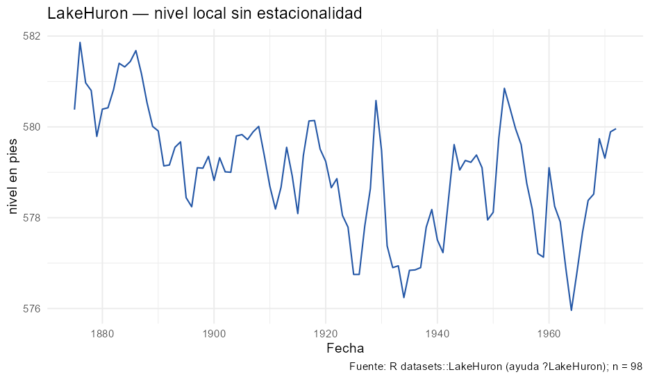

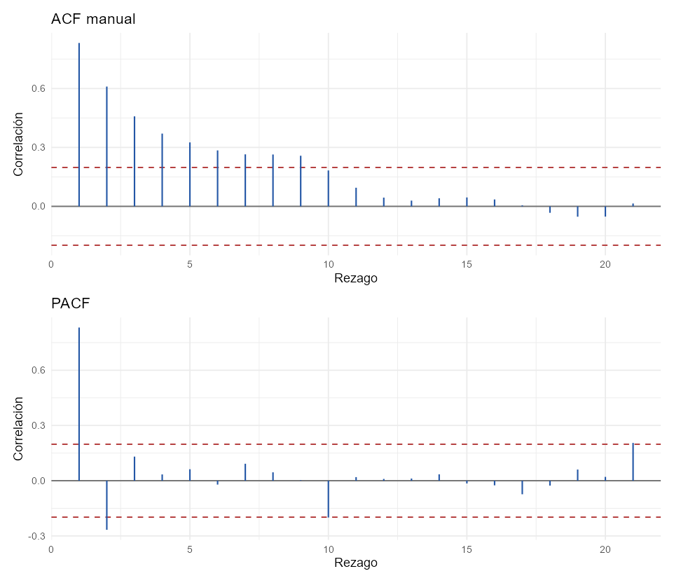

### 4.3.2 Selección de $\alpha$, ajuste y validación

```r
mostrar_ajuste(x)
```

El tramo de estimación contiene **86 observaciones** y la validación conserva las últimas **12 observaciones**. El ajuste seleccionado es **alpha=0.98**.

El óptimo cae en el borde de la rejilla. Esto indica que la búsqueda empuja el parámetro hacia el extremo permitido y que el modelo o la rejilla deben interpretarse con cautela.

| Muestra | MSE | MAD | MAPE | MASE |
| --- | --- | --- | --- | --- |
| Estimación: pronóstico de un paso | 0.5578 | 0.5767 | 0.0996 | 1.0045 |
| Validación: método | 2.1749 | 1.2294 | 0.2129 | 2.1413 |
| Validación: Ingenuo | 2.2384 | 1.2425 | 0.2151 | 2.1642 |

Con el mismo origen y horizonte, el método sí supera al referente según MASE: 2.141 frente a 2.164.

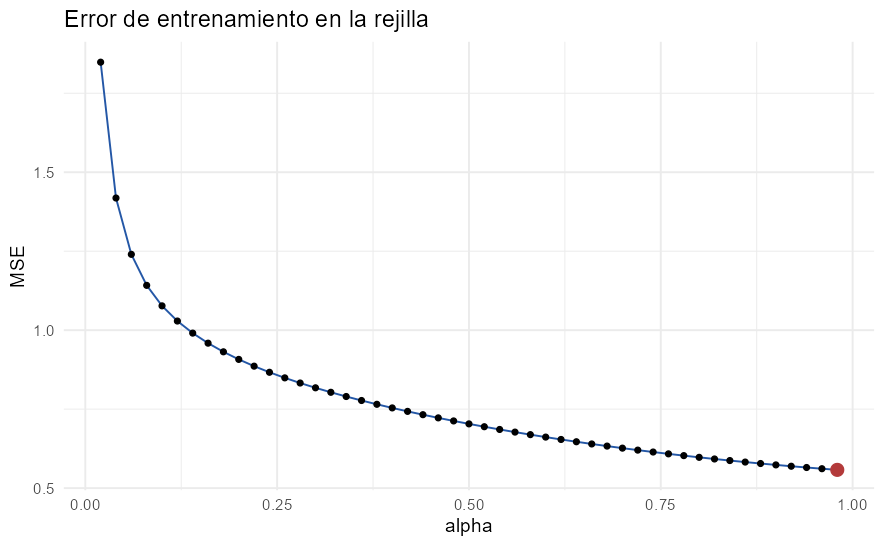

```r
figuras_md(x$figuras["optimizacion"])
```

El valor óptimo $\alpha=0.98$ está en el borde superior de la rejilla y deja casi todo el peso en la última observación. En términos prácticos, SES se aproxima al pronóstico ingenuo; por eso la similitud de sus MASE no debe interpretarse como una mejora sustancial.

### 4.3.3 Validación de los errores

```r
mostrar_diagnosticos(x)
```

Los diagnósticos utilizan **85 errores efectivos** después de retirar las posiciones de calentamiento.

#### 4.3.3.1 Media cero de los errores

1. **Hipótesis:**

$$\begin{aligned}
H_0 &: \mu_e = 0, \\
H_1 &: \mu_e \neq 0.
\end{aligned}$$

2. **Estadístico y distribución bajo H₀:**

$$\begin{aligned}
t &= \frac{\bar e}{s_e/\sqrt{n_e}}, \\[4pt]
t \mid H_0 &\sim t_{84}.
\end{aligned}$$

3. **Región de rechazo con α = 0.05:**

$$|t| > t_{0.975;84} = 1.9886$$

4. **Valor observado y valor p:**

$$t_{\mathrm{obs}} = -0.1944, \qquad p = 0.8463$$

5. **Decisión:** No se rechaza H0 al nivel del 5 %.
6. **Lectura en contexto:** No se detecta sesgo medio en los errores al 5 %.

#### 4.3.3.2 Ljung–Box sobre los errores

1. **Hipótesis:**

$$\begin{aligned}
H_0 &: \rho_1 = \rho_2 = \cdots = \rho_m = 0, \\
H_1 &: \exists\,h \in \{1,\ldots,m\}: \rho_h \neq 0.
\end{aligned}$$

2. **Estadístico y distribución bajo H₀:**

$$\begin{aligned}
Q_m &= T_e(T_e+2) \sum_{h=1}^{m} \frac{r_h^2}{T_e-h}, \\[4pt]
Q_m \mid H_0 &\approx \chi^2_{m-p} = \chi^2_{20}.
\end{aligned}$$

3. **Región de rechazo con α = 0.05:**

$$Q_m > \chi^2_{0.95;20} = 31.4104$$

4. **Valor observado y valor p:**

$$Q_{m,\mathrm{obs}} = 27.6166, \qquad p = 0.1188$$

5. **Decisión:** No se rechaza H0 al nivel del 5 %.
6. **Lectura en contexto:** No se detecta autocorrelación conjunta residual al 5 %.

#### 4.3.3.3 Jarque–Bera

1. **Hipótesis:**

$$\begin{aligned}
H_0 &: A = 0 \text{ y } K = 3, \\
H_1 &: A \neq 0 \text{ o } K \neq 3.
\end{aligned}$$

2. **Estadístico y distribución bajo H₀:**

$$\begin{aligned}
JB &= \frac{n}{6}\left[A^2 + \frac{(K-3)^2}{4}\right], \\[4pt]
JB \mid H_0 &\approx \chi^2_2.
\end{aligned}$$

3. **Región de rechazo con α = 0.05:**

$$JB > \chi^2_{0.95;2} = 5.9915$$

4. **Valor observado y valor p:**

$$JB_{\mathrm{obs}} = 2.7195, \qquad p = 0.2567$$

5. **Decisión:** No se rechaza H0 al nivel del 5 %.
6. **Lectura en contexto:** No se rechaza la compatibilidad aproximada con normalidad.

#### 4.3.3.4 Durbin–Watson

1. **Hipótesis:**

$$\begin{aligned}
H_0 &: \rho_1 = 0, \\
H_1 &: \rho_1 > 0.
\end{aligned}$$

2. **Estadístico y referencia:**

$$\begin{aligned}
d &= \frac{\sum_{t=2}^{n_e}(e_t-e_{t-1})^2}{\sum_{t=1}^{n_e}e_t^2}, \\[4pt]
d_L, d_U &\text{ dependen de } n_e \text{ y del número de regresores}.
\end{aligned}$$

3. **Región de decisión con α = 0.05:**

$$\begin{cases} d<d_L &\Rightarrow \text{ rechazar } H_0, \\[2pt] d>d_U &\Rightarrow \text{ no rechazar } H_0, \\[2pt] d_L\le d\le d_U &\Rightarrow \text{ resultado inconcluso}. \end{cases}$$

4. **Valor observado:**

$$d_{\mathrm{obs}} = 1.5456, \qquad p = \mathrm{NA}$$

5. **Decisión:** no se calcula una decisión formal; este método no tiene una matriz de diseño fija (no es una regresión), y la rúbrica exige las cotas $d_L$/$d_U$ únicamente para los tres ejemplos de tendencia.
6. **Lectura en contexto:** valores muy inferiores a 2 son compatibles descriptivamente con autocorrelación positiva, pero no sustituyen una decisión formal.

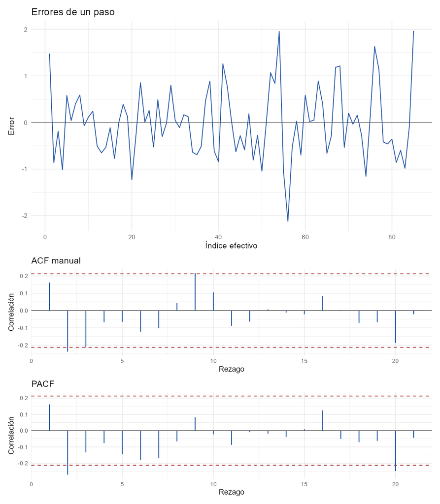

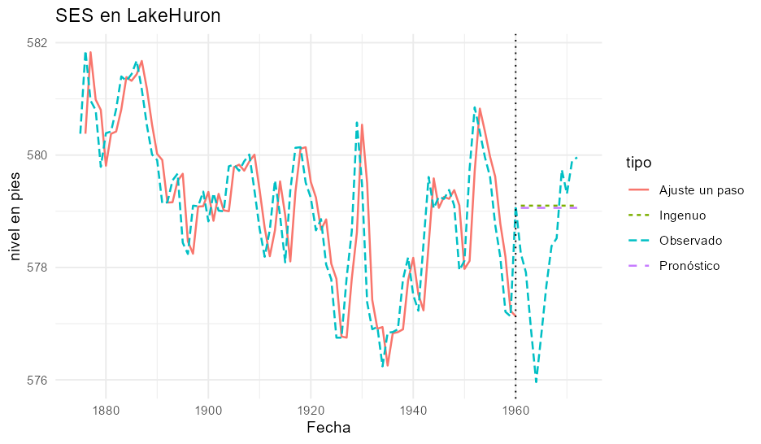

### 4.3.4 Conclusión y recomendación

```r
cierre_md(x)
```

**Conclusión.** Se ajustó SES con alpha=0.98. En las 12 observaciones de validación obtuvo MSE = 2.175, MAD = 1.229, MAPE = 0.213 y MASE = 2.141. El referente ingenuo produjo MASE = 2.164. En los errores, Ljung–Box dio p = 0.1188 y la prueba de media cero dio p = 0.8463.

**Recomendación.** El resultado podría servir a un gestor que siga el nivel anual del lago solamente hasta un horizonte de 12 años. Su límite principal es que α está en el borde superior y el método se aproxima al ingenuo; esto se evidencia con MASE = 2.141 y p de Ljung–Box residual = 0.1188.

## 4.4 Doble media móvil sobre `WWWusage`

### 4.4.1 Serie y patrón antes del ajuste

```r
x <- resultados[[4]]
mostrar_serie(x)
```

| Campo | Valor |
| --- | --- |
| Objeto de R | WWWusage |
| Fuente documentada en help() | Durbin y Koopman (2001), Time Series Analysis by State Space Methods, Oxford University Press. |
| Unidad | usuarios conectados |
| Frecuencia | 1 |
| Rango | índices 1 a 100; help() no proporciona fechas calendario |
| Observaciones | 100 |

**Contrastes individuales de la ACF.** Bajo H0: ρ_h = 0, se compara cada r_h con la banda ±0.209. Quedan fuera de la banda: h=1 (r=0.960); h=2 (r=0.893); h=3 (r=0.811); h=4 (r=0.719); h=5 (r=0.618); h=6 (r=0.509); h=7 (r=0.397); h=8 (r=0.292); h=14 (r=-0.222); h=15 (r=-0.277); h=16 (r=-0.317); h=17 (r=-0.347); h=18 (r=-0.367); h=19 (r=-0.376); h=20 (r=-0.371); h=21 (r=-0.353); h=22 (r=-0.326). Estos contrastes son descriptivos e individuales; no sustituyen la prueba conjunta de Ljung–Box.

**Lectura previa del patrón.** El crecimiento es marcado y la ACF decrece lentamente. La doble media móvil intenta representar simultáneamente nivel y pendiente local.

#### 4.4.1.1 Ljung–Box sobre la serie

1. **Hipótesis:**

$$\begin{aligned}
H_0 &: \rho_1 = \rho_2 = \cdots = \rho_m = 0, \\
H_1 &: \exists\,h \in \{1,\ldots,m\}: \rho_h \neq 0.
\end{aligned}$$

2. **Estadístico y distribución bajo H₀:**

$$\begin{aligned}
Q_m &= T(T+2) \sum_{h=1}^{m} \frac{r_h^2}{T-h}, \\[4pt]
Q_m \mid H_0 &\approx \chi^2_{22}.
\end{aligned}$$

3. **Región de rechazo con α = 0.05:**

$$Q_m > \chi^2_{0.95;22} = 33.9244$$

4. **Valor observado y valor p:**

$$Q_{m,\mathrm{obs}} = 473.7733, \qquad p = 2.12 \times 10^{-86}$$

5. **Decisión:** Se rechaza H0 al nivel del 5 %.
6. **Lectura en contexto:** La serie no se comporta como ruido blanco: existe dependencia conjunta antes de ajustar el método.

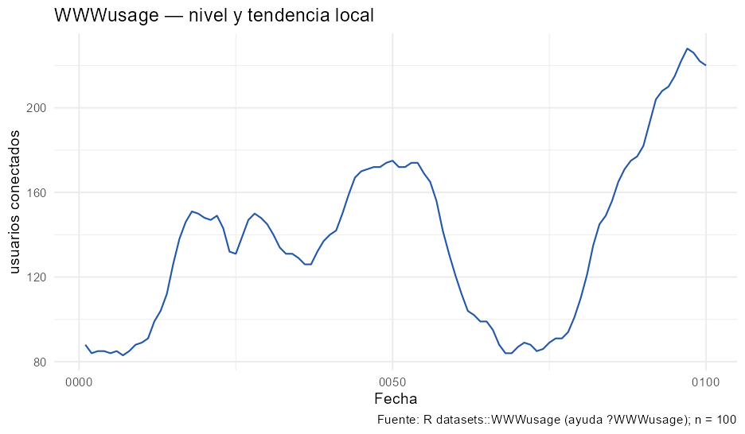

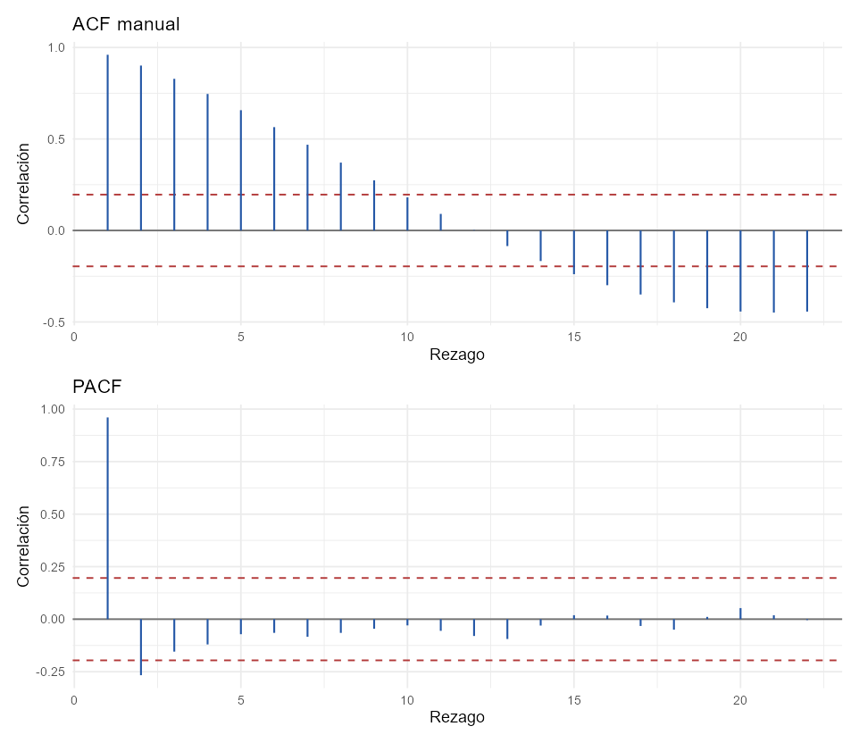

### 4.4.2 Selección de ventana, ajuste y validación

```r
mostrar_ajuste(x)
```

El tramo de estimación contiene **88 observaciones** y la validación conserva las últimas **12 observaciones**. El ajuste seleccionado es **k=2**.

El óptimo cae en el borde de la rejilla. Esto indica que la búsqueda empuja el parámetro hacia el extremo permitido y que el modelo o la rejilla deben interpretarse con cautela.

| Muestra | MSE | MAD | MAPE | MASE |
| --- | --- | --- | --- | --- |
| Estimación: pronóstico de un paso | 22.6956 | 3.8294 | 3.0668 | 0.8609 |
| Validación: método | 50.9167 | 6.0833 | 2.8764 | 1.3676 |
| Validación: Ingenuo | 1415.4167 | 33.9167 | 15.6886 | 7.6247 |

Con el mismo origen y horizonte, el método sí supera al referente según MASE: 1.368 frente a 7.625.

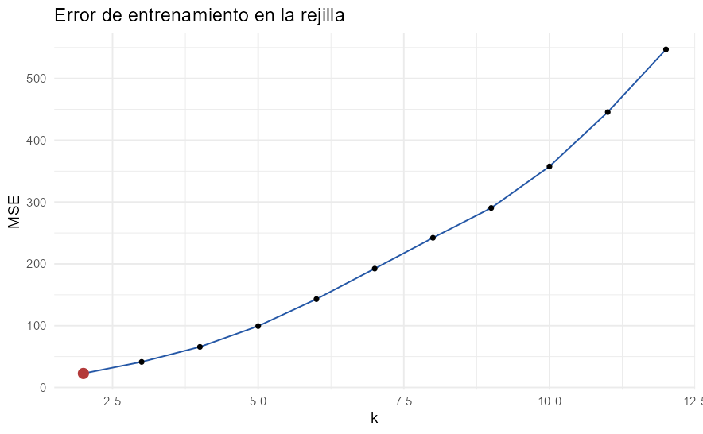

```r
figuras_md(x$figuras["optimizacion"])
```

La ventana óptima $k=2$ es el extremo inferior permitido. Esto indica que la dinámica reciente domina el ajuste y que ampliar la ventana empeora el MSE de un paso.

### 4.4.3 Validación de los errores

```r
mostrar_diagnosticos(x)
```

Los diagnósticos utilizan **85 errores efectivos** después de retirar las posiciones de calentamiento.

#### 4.4.3.1 Media cero de los errores

1. **Hipótesis:**

$$\begin{aligned}
H_0 &: \mu_e = 0, \\
H_1 &: \mu_e \neq 0.
\end{aligned}$$

2. **Estadístico y distribución bajo H₀:**

$$\begin{aligned}
t &= \frac{\bar e}{s_e/\sqrt{n_e}}, \\[4pt]
t \mid H_0 &\sim t_{84}.
\end{aligned}$$

3. **Región de rechazo con α = 0.05:**

$$|t| > t_{0.975;84} = 1.9886$$

4. **Valor observado y valor p:**

$$t_{\mathrm{obs}} = 0.2377, \qquad p = 0.8127$$

5. **Decisión:** No se rechaza H0 al nivel del 5 %.
6. **Lectura en contexto:** No se detecta sesgo medio en los errores al 5 %.

#### 4.4.3.2 Ljung–Box sobre los errores

1. **Hipótesis:**

$$\begin{aligned}
H_0 &: \rho_1 = \rho_2 = \cdots = \rho_m = 0, \\
H_1 &: \exists\,h \in \{1,\ldots,m\}: \rho_h \neq 0.
\end{aligned}$$

2. **Estadístico y distribución bajo H₀:**

$$\begin{aligned}
Q_m &= T_e(T_e+2) \sum_{h=1}^{m} \frac{r_h^2}{T_e-h}, \\[4pt]
Q_m \mid H_0 &\approx \chi^2_{m-p} = \chi^2_{19}.
\end{aligned}$$

3. **Región de rechazo con α = 0.05:**

$$Q_m > \chi^2_{0.95;19} = 30.1435$$

4. **Valor observado y valor p:**

$$Q_{m,\mathrm{obs}} = 63.2611, \qquad p = 1.17 \times 10^{-6}$$

5. **Decisión:** Se rechaza H0 al nivel del 5 %.
6. **Lectura en contexto:** Permanece autocorrelación aprovechable: el método no extrajo toda la estructura temporal.

#### 4.4.3.3 Jarque–Bera

1. **Hipótesis:**

$$\begin{aligned}
H_0 &: A = 0 \text{ y } K = 3, \\
H_1 &: A \neq 0 \text{ o } K \neq 3.
\end{aligned}$$

2. **Estadístico y distribución bajo H₀:**

$$\begin{aligned}
JB &= \frac{n}{6}\left[A^2 + \frac{(K-3)^2}{4}\right], \\[4pt]
JB \mid H_0 &\approx \chi^2_2.
\end{aligned}$$

3. **Región de rechazo con α = 0.05:**

$$JB > \chi^2_{0.95;2} = 5.9915$$

4. **Valor observado y valor p:**

$$JB_{\mathrm{obs}} = 1.2294, \qquad p = 0.5408$$

5. **Decisión:** No se rechaza H0 al nivel del 5 %.
6. **Lectura en contexto:** No se rechaza la compatibilidad aproximada con normalidad.

#### 4.4.3.4 Durbin–Watson

1. **Hipótesis:**

$$\begin{aligned}
H_0 &: \rho_1 = 0, \\
H_1 &: \rho_1 > 0.
\end{aligned}$$

2. **Estadístico y referencia:**

$$\begin{aligned}
d &= \frac{\sum_{t=2}^{n_e}(e_t-e_{t-1})^2}{\sum_{t=1}^{n_e}e_t^2}, \\[4pt]
d_L, d_U &\text{ dependen de } n_e \text{ y del número de regresores}.
\end{aligned}$$

3. **Región de decisión con α = 0.05:**

$$\begin{cases} d<d_L &\Rightarrow \text{ rechazar } H_0, \\[2pt] d>d_U &\Rightarrow \text{ no rechazar } H_0, \\[2pt] d_L\le d\le d_U &\Rightarrow \text{ resultado inconcluso}. \end{cases}$$

4. **Valor observado:**

$$d_{\mathrm{obs}} = 1.1830, \qquad p = \mathrm{NA}$$

5. **Decisión:** no se calcula una decisión formal; este método no tiene una matriz de diseño fija (no es una regresión), y la rúbrica exige las cotas $d_L$/$d_U$ únicamente para los tres ejemplos de tendencia.
6. **Lectura en contexto:** valores muy inferiores a 2 son compatibles descriptivamente con autocorrelación positiva, pero no sustituyen una decisión formal.

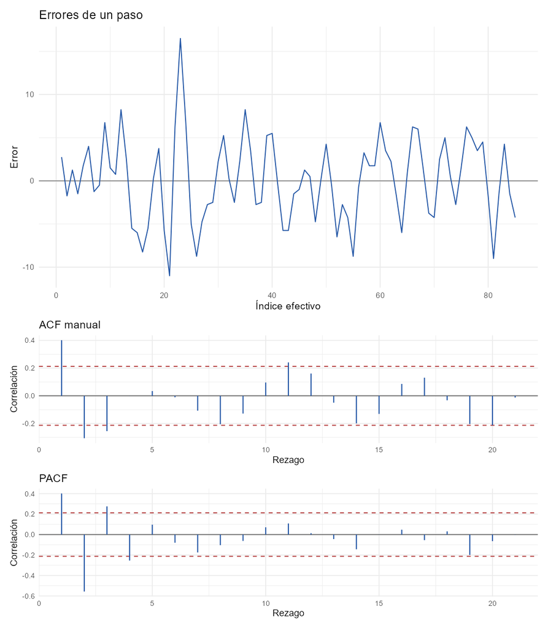

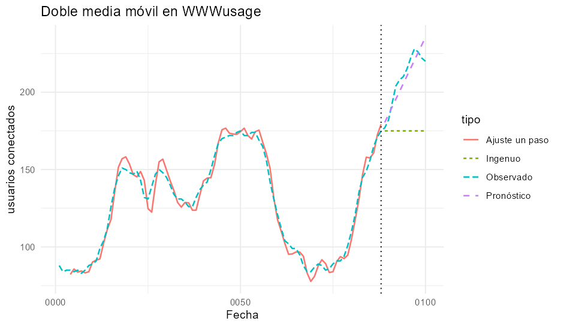

### 4.4.4 Conclusión y recomendación

```r
cierre_md(x)
```

**Conclusión.** Se ajustó Doble media móvil con k=2. En las 12 observaciones de validación obtuvo MSE = 50.917, MAD = 6.083, MAPE = 2.876 y MASE = 1.368. El referente ingenuo produjo MASE = 7.625. En los errores, Ljung–Box dio p = 1.17e-06 y la prueba de media cero dio p = 0.8127.

**Recomendación.** El resultado podría servir a un administrador que anticipe la carga inmediata de usuarios solamente hasta un horizonte de 12 observaciones de la escala original. Su límite principal es que la tendencia local no elimina toda la autocorrelación residual; esto se evidencia con MASE = 1.368 y p de Ljung–Box residual = 1.17e-06.

## 4.5 Tendencia lineal sobre `austres`

### 4.5.1 Serie y patrón antes del ajuste

```r
x <- resultados[[5]]
mostrar_serie(x)
```

| Campo | Valor |
| --- | --- |
| Objeto de R | austres |
| Fuente documentada en help() | P. J. Brockwell y R. A. Davis (1996), Introduction to Time Series and Forecasting, Springer. |
| Unidad | miles de residentes |
| Frecuencia | 4 |
| Rango | 1971-04-01 a 1993-04-01 |
| Observaciones | 89 |

**Contrastes individuales de la ACF.** Bajo H0: ρ_h = 0, se compara cada r_h con la banda ±0.223. Quedan fuera de la banda: h=1 (r=0.958); h=2 (r=0.916); h=3 (r=0.874); h=4 (r=0.833); h=5 (r=0.792); h=6 (r=0.752); h=7 (r=0.712); h=8 (r=0.673); h=9 (r=0.634); h=10 (r=0.596); h=11 (r=0.559); h=12 (r=0.523); h=13 (r=0.488); h=14 (r=0.453); h=15 (r=0.419); h=16 (r=0.385); h=17 (r=0.352); h=18 (r=0.319); h=19 (r=0.286). Estos contrastes son descriptivos e individuales; no sustituyen la prueba conjunta de Ljung–Box.

**Lectura previa del patrón.** La trayectoria es creciente y visualmente casi recta, con un leve cambio de pendiente entre los años 1970 y 1980. No se observa oscilación estacional trimestral pese a la frecuencia 4 de la serie.

#### 4.5.1.1 Ljung–Box sobre la serie

1. **Hipótesis:**

$$\begin{aligned}
H_0 &: \rho_1 = \rho_2 = \cdots = \rho_m = 0, \\
H_1 &: \exists\,h \in \{1,\ldots,m\}: \rho_h \neq 0.
\end{aligned}$$

2. **Estadístico y distribución bajo H₀:**

$$\begin{aligned}
Q_m &= T(T+2) \sum_{h=1}^{m} \frac{r_h^2}{T-h}, \\[4pt]
Q_m \mid H_0 &\approx \chi^2_{19}.
\end{aligned}$$

3. **Región de rechazo con α = 0.05:**

$$Q_m > \chi^2_{0.95;19} = 30.1435$$

4. **Valor observado y valor p:**

$$Q_{m,\mathrm{obs}} = 676.2783, \qquad p = 3.8 \times 10^{-131}$$

5. **Decisión:** Se rechaza H0 al nivel del 5 %.
6. **Lectura en contexto:** La serie no se comporta como ruido blanco: existe dependencia conjunta antes de ajustar el método.

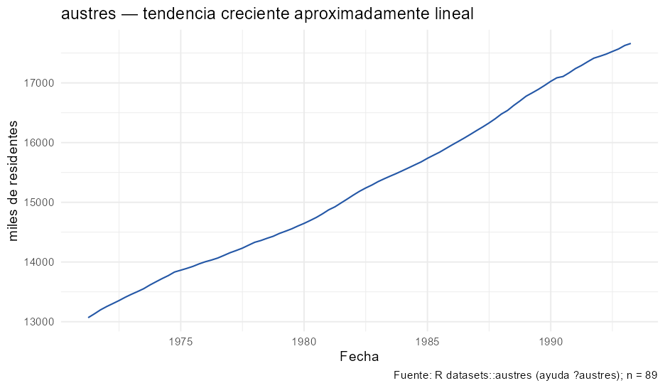

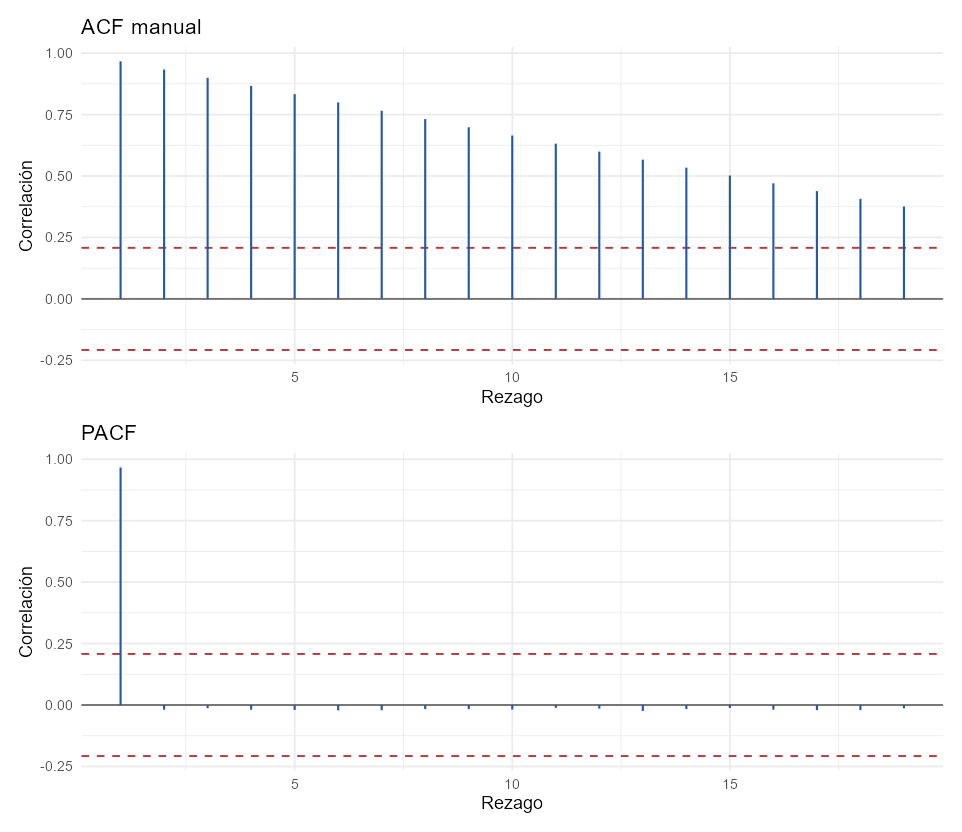

### 4.5.2 Ajuste, coeficientes y validación

```r
mostrar_ajuste(x)
```

El tramo de estimación contiene **77 observaciones** y la validación conserva las últimas **12 observaciones**. El ajuste seleccionado es **lineal; R2=0.993**.

Este método no requiere seleccionar parámetros mediante una rejilla; sus parámetros se estiman directamente con el tramo de estimación.

| Muestra | MSE | MAD | MAPE | MASE |
| --- | --- | --- | --- | --- |
| Estimación: pronóstico de un paso | 9748.5966 | 75.4839 | 0.4793 | 0.3599 |
| Validación: método | 44430.9654 | 210.0804 | 1.2071 | 1.0017 |
| Validación: Ingenuo estacional | 200633.9333 | 417.4167 | 2.3898 | 1.9903 |

Con el mismo origen y horizonte, el método sí supera al referente según MASE: 1.002 frente a 1.990.

```r
mostrar_coeficientes(x)
```

### 4.5.3 Coeficientes y contrastes robustos

| Término | Estimación | SE ordinario | SE HAC | t HAC | p HAC |
| --- | --- | --- | --- | --- | --- |
| intercepto | 12963.28824 | 21.95795 | 40.73278 | 318.25200 | 3.61e-119 |
| t | 50.70746 | 0.48916 | 1.04905 | 48.33646 | 2.81e-58 |

#### 4.5.3.1 Coeficiente intercepto con error HAC

1. **Hipótesis:**

$$\begin{aligned}
H_0 &: \beta_{0} = 0, \\
H_1 &: \beta_{0} \neq 0.
\end{aligned}$$

2. **Estadístico y distribución bajo H₀:**

$$\begin{aligned}
t_{\mathrm{HAC}} &= \frac{\widehat{\beta}_{0}}{\operatorname{SE}_{\mathrm{HAC}}(\widehat{\beta}_{0})}, \\[4pt]
t_{\mathrm{HAC}} \mid H_0 &\sim t_{75}.
\end{aligned}$$

3. **Región de rechazo con α = 0.05:**

$$|t_{\mathrm{HAC}}| > t_{0.975;75} = 1.9921$$

4. **Valor observado y valor p:**

$$t_{\mathrm{HAC,obs}} = 318.2520, \qquad p = 3.61 \times 10^{-119}$$

5. **Decisión:** Se rechaza H0 al nivel del 5 %.
6. **Lectura en contexto:** Hay evidencia robusta de que el coeficiente intercepto contribuye a la tendencia.

#### 4.5.3.2 Coeficiente t con error HAC

1. **Hipótesis:**

$$\begin{aligned}
H_0 &: \beta_{1} = 0, \\
H_1 &: \beta_{1} \neq 0.
\end{aligned}$$

2. **Estadístico y distribución bajo H₀:**

$$\begin{aligned}
t_{\mathrm{HAC}} &= \frac{\widehat{\beta}_{1}}{\operatorname{SE}_{\mathrm{HAC}}(\widehat{\beta}_{1})}, \\[4pt]
t_{\mathrm{HAC}} \mid H_0 &\sim t_{75}.
\end{aligned}$$

3. **Región de rechazo con α = 0.05:**

$$|t_{\mathrm{HAC}}| > t_{0.975;75} = 1.9921$$

4. **Valor observado y valor p:**

$$t_{\mathrm{HAC,obs}} = 48.3365, \qquad p = 2.81 \times 10^{-58}$$

5. **Decisión:** Se rechaza H0 al nivel del 5 %.
6. **Lectura en contexto:** Hay evidencia robusta de que el coeficiente t contribuye a la tendencia.

Los coeficientes se estiman con las ecuaciones normales. Las decisiones anteriores emplean `se_hac`, no el error ordinario, porque la autocorrelación residual vuelve poco confiable la inferencia ordinaria.

### 4.5.4 Supuestos y validación de los errores

```r
mostrar_diagnosticos(x)
```

Los diagnósticos utilizan **75 errores efectivos** después de retirar las posiciones de calentamiento.

#### 4.5.4.1 Media cero de los errores

1. **Hipótesis:**

$$\begin{aligned}
H_0 &: \mu_e = 0, \\
H_1 &: \mu_e \neq 0.
\end{aligned}$$

2. **Estadístico y distribución bajo H₀:**

$$\begin{aligned}
t &= \frac{\bar e}{s_e/\sqrt{n_e}}, \\[4pt]
t \mid H_0 &\sim t_{74}.
\end{aligned}$$

3. **Región de rechazo con α = 0.05:**

$$|t| > t_{0.975;74} = 1.9925$$

4. **Valor observado y valor p:**

$$t_{\mathrm{obs}} = 4.5224, \qquad p = 2.28 \times 10^{-5}$$

5. **Decisión:** Se rechaza H0 al nivel del 5 %.
6. **Lectura en contexto:** Los errores presentan sesgo medio estadísticamente detectable.

#### 4.5.4.2 Ljung–Box sobre los errores

1. **Hipótesis:**

$$\begin{aligned}
H_0 &: \rho_1 = \rho_2 = \cdots = \rho_m = 0, \\
H_1 &: \exists\,h \in \{1,\ldots,m\}: \rho_h \neq 0.
\end{aligned}$$

2. **Estadístico y distribución bajo H₀:**

$$\begin{aligned}
Q_m &= T_e(T_e+2) \sum_{h=1}^{m} \frac{r_h^2}{T_e-h}, \\[4pt]
Q_m \mid H_0 &\approx \chi^2_{m-p} = \chi^2_{16}.
\end{aligned}$$

3. **Región de rechazo con α = 0.05:**

$$Q_m > \chi^2_{0.95;16} = 26.2962$$

4. **Valor observado y valor p:**

$$Q_{m,\mathrm{obs}} = 532.8699, \qquad p = 3.78 \times 10^{-103}$$

5. **Decisión:** Se rechaza H0 al nivel del 5 %.
6. **Lectura en contexto:** Permanece autocorrelación aprovechable: el método no extrajo toda la estructura temporal.

#### 4.5.4.3 Jarque–Bera

1. **Hipótesis:**

$$\begin{aligned}
H_0 &: A = 0 \text{ y } K = 3, \\
H_1 &: A \neq 0 \text{ o } K \neq 3.
\end{aligned}$$

2. **Estadístico y distribución bajo H₀:**

$$\begin{aligned}
JB &= \frac{n}{6}\left[A^2 + \frac{(K-3)^2}{4}\right], \\[4pt]
JB \mid H_0 &\approx \chi^2_2.
\end{aligned}$$

3. **Región de rechazo con α = 0.05:**

$$JB > \chi^2_{0.95;2} = 5.9915$$

4. **Valor observado y valor p:**

$$JB_{\mathrm{obs}} = 6.3737, \qquad p = 0.0413$$

5. **Decisión:** Se rechaza H0 al nivel del 5 %.
6. **Lectura en contexto:** Los errores no son compatibles con normalidad aproximada según asimetría y curtosis.

#### 4.5.4.4 Durbin–Watson

1. **Hipótesis:**

$$\begin{aligned}
H_0 &: \rho_1 = 0, \\
H_1 &: \rho_1 > 0.
\end{aligned}$$

2. **Estadístico y distribución bajo H₀:**

$$\begin{aligned}
d &= \frac{\sum_{t=2}^{n_e}(e_t-e_{t-1})^2}{\sum_{t=1}^{n_e}e_t^2}, \\[4pt]
d \mid H_0 &\sim \textstyle\sum_i \lambda_i Z_i \big/ \sum_i Z_i,\ Z_i \overset{iid}{\sim} \chi^2_1.
\end{aligned}$$

3. **Región de rechazo con α = 0.05 (valor p exacto, método de Imhof 1961, en vez de las cotas $d_L$/$d_U$ tabuladas):**

$$p = P(d \le d_{\mathrm{obs}} \mid H_0) < 0.05 \;\Rightarrow\; \text{rechazar } H_0$$

4. **Valor observado y valor p:**

$$d_{\mathrm{obs}} = 0.0102, \qquad p = 2.34 \times 10^{-7}$$

5. **Decisión:** Se rechaza H0 al nivel del 5 %.
6. **Lectura en contexto:** Hay evidencia de autocorrelación positiva de primer orden en los errores; los valores p ordinarios de los coeficientes no son interpretables y la decisión se apoya en el error estándar HAC.

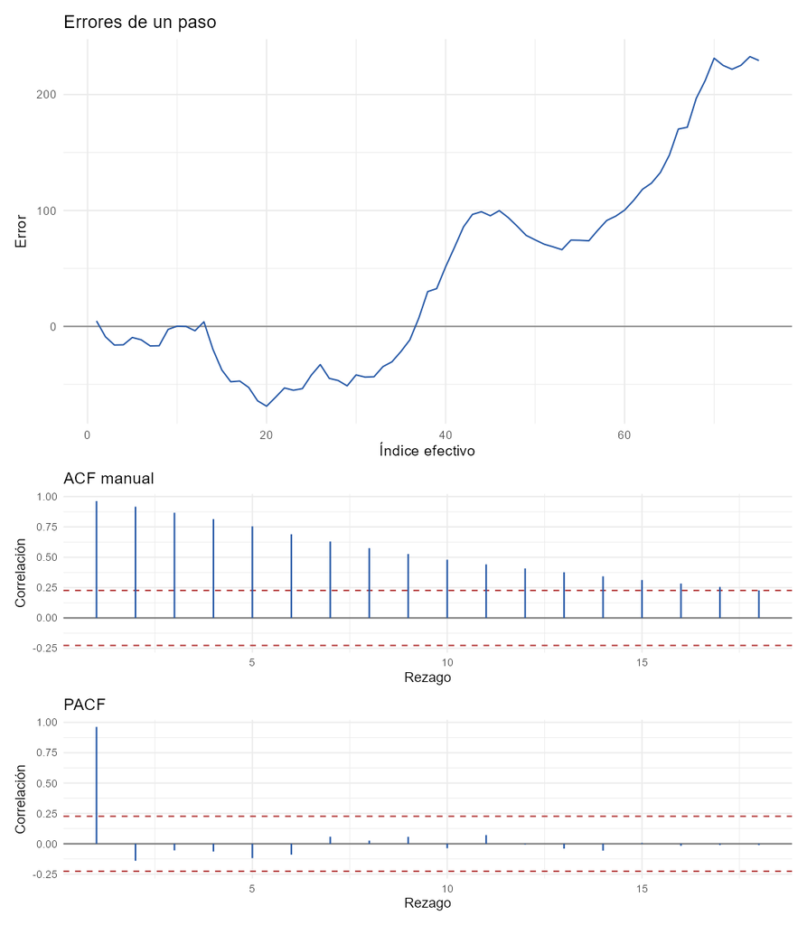

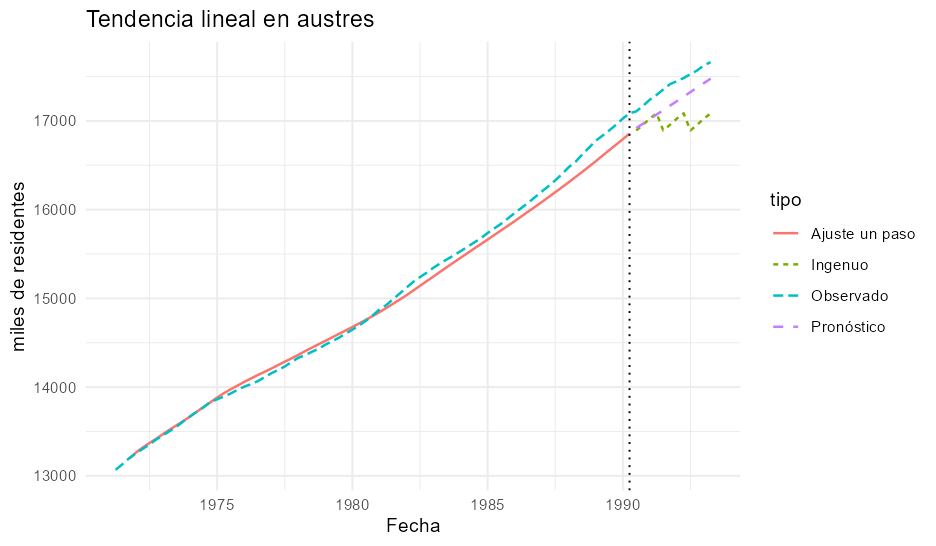

### 4.5.5 Conclusión y recomendación

```r
cierre_md(x)
```

**Conclusión.** Se ajustó Tendencia lineal con lineal; R2=0.993. En las 12 observaciones de validación obtuvo MSE = 44430.965, MAD = 210.080, MAPE = 1.207 y MASE = 1.002. El referente ingenuo estacional produjo MASE = 1.990. En los errores, Ljung–Box dio p = 3.78e-103 y la prueba de media cero dio p = 2.28e-05.

**Recomendación.** El resultado podría servir a un planificador demográfico que proyecte la población residente en el corto plazo solamente hasta un horizonte de 12 trimestres. Su límite principal es que la recta omite curvatura y extrapola con errores sesgados; esto se evidencia con MASE = 1.002 y p de Ljung–Box residual = 3.78e-103.

## 4.6 Tendencia cuadrática sobre `airmiles`

### 4.6.1 Serie y patrón antes del ajuste

```r
x <- resultados[[6]]
mostrar_serie(x)
```

| Campo | Valor |
| --- | --- |
| Objeto de R | airmiles |
| Fuente documentada en help() | F.A.A. Statistical Handbook of Aviation. |
| Unidad | millas-pasajero (millones) |
| Frecuencia | 1 |
| Rango | 1937-01-01 a 1960-01-01 |
| Observaciones | 24 |

**Lectura previa del patrón.** El crecimiento se acelera y una parábola puede representar esa curvatura mejor que una recta, con el riesgo de extrapolar demasiado rápido.

#### 4.6.1.1 Ljung–Box sobre la serie

1. **Hipótesis:**

$$\begin{aligned}
H_0 &: \rho_1 = \rho_2 = \cdots = \rho_m = 0, \\
H_1 &: \exists\,h \in \{1,\ldots,m\}: \rho_h \neq 0.
\end{aligned}$$

2. **Estadístico y distribución bajo H₀:**

$$\begin{aligned}
Q_m &= T(T+2) \sum_{h=1}^{m} \frac{r_h^2}{T-h}, \\[4pt]
Q_m \mid H_0 &\approx \chi^2_{5}.
\end{aligned}$$

3. **Región de rechazo con α = 0.05:**

$$Q_m > \chi^2_{0.95;5} = 11.0705$$

4. **Valor observado y valor p:**

$$Q_{m,\mathrm{obs}} = 36.1299, \qquad p = 8.95 \times 10^{-7}$$

5. **Decisión:** Se rechaza H0 al nivel del 5 %.
6. **Lectura en contexto:** La serie no se comporta como ruido blanco: existe dependencia conjunta antes de ajustar el método.

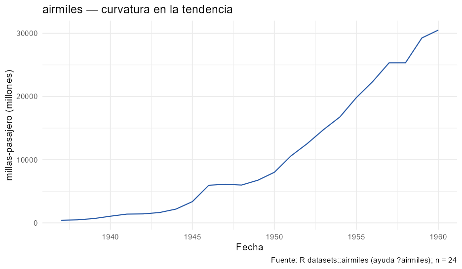

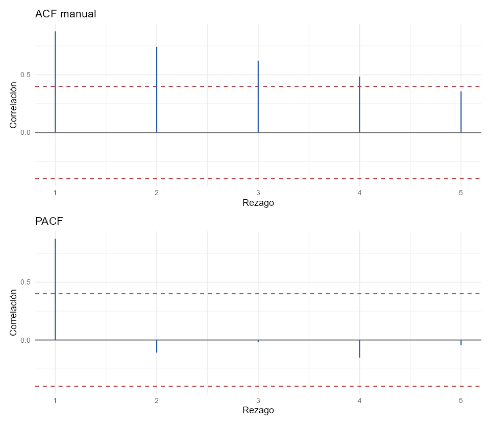

### 4.6.2 Ajuste, coeficientes y validación

```r
mostrar_ajuste(x)
```

El tramo de estimación contiene **20 observaciones** y la validación conserva las últimas **4 observaciones**. El ajuste seleccionado es **cuadratica; R2=0.989**.

Este método no requiere seleccionar parámetros mediante una rejilla; sus parámetros se estiman directamente con el tramo de estimación.

| Muestra | MSE | MAD | MAPE | MASE |
| --- | --- | --- | --- | --- |
| Estimación: pronóstico de un paso | 1150676.5640 | 892.1322 | 14.4129 | 0.7633 |
| Validación: método | 2416497.7367 | 1408.8869 | 5.0918 | 1.2055 |
| Validación: Ingenuo | 32979149.5000 | 5254.5000 | 18.4572 | 4.4959 |

Con el mismo origen y horizonte, el método sí supera al referente según MASE: 1.205 frente a 4.496.

```r
mostrar_coeficientes(x)
```

### 4.6.3 Coeficientes y contrastes robustos

| Término | Estimación | SE ordinario | SE HAC | t HAC | p HAC |
| --- | --- | --- | --- | --- | --- |
| intercepto | 1420.12456 | 554.89763 | 517.16241 | 2.74599 | 0.01378 |
| t | -473.93042 | 121.69765 | 149.35683 | -3.17314 | 0.00556 |
| t2 | 74.32923 | 5.62909 | 6.87577 | 10.81031 | 4.88e-09 |

#### 4.6.3.1 Coeficiente intercepto con error HAC

1. **Hipótesis:**

$$\begin{aligned}
H_0 &: \beta_{0} = 0, \\
H_1 &: \beta_{0} \neq 0.
\end{aligned}$$

2. **Estadístico y distribución bajo H₀:**

$$\begin{aligned}
t_{\mathrm{HAC}} &= \frac{\widehat{\beta}_{0}}{\operatorname{SE}_{\mathrm{HAC}}(\widehat{\beta}_{0})}, \\[4pt]
t_{\mathrm{HAC}} \mid H_0 &\sim t_{17}.
\end{aligned}$$

3. **Región de rechazo con α = 0.05:**

$$|t_{\mathrm{HAC}}| > t_{0.975;17} = 2.1098$$

4. **Valor observado y valor p:**

$$t_{\mathrm{HAC,obs}} = 2.7460, \qquad p = 0.0138$$

5. **Decisión:** Se rechaza H0 al nivel del 5 %.
6. **Lectura en contexto:** Hay evidencia robusta de que el coeficiente intercepto contribuye a la tendencia.

#### 4.6.3.2 Coeficiente t con error HAC

1. **Hipótesis:**

$$\begin{aligned}
H_0 &: \beta_{1} = 0, \\
H_1 &: \beta_{1} \neq 0.
\end{aligned}$$

2. **Estadístico y distribución bajo H₀:**

$$\begin{aligned}
t_{\mathrm{HAC}} &= \frac{\widehat{\beta}_{1}}{\operatorname{SE}_{\mathrm{HAC}}(\widehat{\beta}_{1})}, \\[4pt]
t_{\mathrm{HAC}} \mid H_0 &\sim t_{17}.
\end{aligned}$$

3. **Región de rechazo con α = 0.05:**

$$|t_{\mathrm{HAC}}| > t_{0.975;17} = 2.1098$$

4. **Valor observado y valor p:**

$$t_{\mathrm{HAC,obs}} = -3.1731, \qquad p = 0.0056$$

5. **Decisión:** Se rechaza H0 al nivel del 5 %.
6. **Lectura en contexto:** Hay evidencia robusta de que el coeficiente t contribuye a la tendencia.

#### 4.6.3.3 Coeficiente t2 con error HAC

1. **Hipótesis:**

$$\begin{aligned}
H_0 &: \beta_{2} = 0, \\
H_1 &: \beta_{2} \neq 0.
\end{aligned}$$

2. **Estadístico y distribución bajo H₀:**

$$\begin{aligned}
t_{\mathrm{HAC}} &= \frac{\widehat{\beta}_{2}}{\operatorname{SE}_{\mathrm{HAC}}(\widehat{\beta}_{2})}, \\[4pt]
t_{\mathrm{HAC}} \mid H_0 &\sim t_{17}.
\end{aligned}$$

3. **Región de rechazo con α = 0.05:**

$$|t_{\mathrm{HAC}}| > t_{0.975;17} = 2.1098$$

4. **Valor observado y valor p:**

$$t_{\mathrm{HAC,obs}} = 10.8103, \qquad p = 4.88 \times 10^{-9}$$

5. **Decisión:** Se rechaza H0 al nivel del 5 %.
6. **Lectura en contexto:** Hay evidencia robusta de que el coeficiente t2 contribuye a la tendencia.

El término $t^2$ permite curvatura. Aunque la mejora frente a la recta sea grande, una parábola puede crecer de forma poco realista al extrapolar lejos de la muestra; el horizonte de cuatro años es parte esencial de la recomendación.

### 4.6.4 Supuestos y validación de los errores

```r
mostrar_diagnosticos(x)
```

Los diagnósticos utilizan **17 errores efectivos** después de retirar las posiciones de calentamiento.

#### 4.6.4.1 Media cero de los errores

1. **Hipótesis:**

$$\begin{aligned}
H_0 &: \mu_e = 0, \\
H_1 &: \mu_e \neq 0.
\end{aligned}$$

2. **Estadístico y distribución bajo H₀:**

$$\begin{aligned}
t &= \frac{\bar e}{s_e/\sqrt{n_e}}, \\[4pt]
t \mid H_0 &\sim t_{16}.
\end{aligned}$$

3. **Región de rechazo con α = 0.05:**

$$|t| > t_{0.975;16} = 2.1199$$

4. **Valor observado y valor p:**

$$t_{\mathrm{obs}} = 1.2923, \qquad p = 0.2146$$

5. **Decisión:** No se rechaza H0 al nivel del 5 %.
6. **Lectura en contexto:** No se detecta sesgo medio en los errores al 5 %.

#### 4.6.4.2 Ljung–Box sobre los errores

1. **Hipótesis:**

$$\begin{aligned}
H_0 &: \rho_1 = \rho_2 = \cdots = \rho_m = 0, \\
H_1 &: \exists\,h \in \{1,\ldots,m\}: \rho_h \neq 0.
\end{aligned}$$

2. **Estadístico y distribución bajo H₀:**

$$\begin{aligned}
Q_m &= T_e(T_e+2) \sum_{h=1}^{m} \frac{r_h^2}{T_e-h}, \\[4pt]
Q_m \mid H_0 &\approx \chi^2_{m-p} = \chi^2_{1}.
\end{aligned}$$

3. **Región de rechazo con α = 0.05:**

$$Q_m > \chi^2_{0.95;1} = 3.8415$$

4. **Valor observado y valor p:**

$$Q_{m,\mathrm{obs}} = 13.0662, \qquad p = 3.01 \times 10^{-4}$$

5. **Decisión:** Se rechaza H0 al nivel del 5 %.
6. **Lectura en contexto:** Permanece autocorrelación aprovechable: el método no extrajo toda la estructura temporal.

#### 4.6.4.3 Jarque–Bera

1. **Hipótesis:**

$$\begin{aligned}
H_0 &: A = 0 \text{ y } K = 3, \\
H_1 &: A \neq 0 \text{ o } K \neq 3.
\end{aligned}$$

2. **Estadístico y distribución bajo H₀:**

$$\begin{aligned}
JB &= \frac{n}{6}\left[A^2 + \frac{(K-3)^2}{4}\right], \\[4pt]
JB \mid H_0 &\approx \chi^2_2.
\end{aligned}$$

3. **Región de rechazo con α = 0.05:**

$$JB > \chi^2_{0.95;2} = 5.9915$$

4. **Valor observado y valor p:**

$$JB_{\mathrm{obs}} = 0.4207, \qquad p = 0.8103$$

5. **Decisión:** No se rechaza H0 al nivel del 5 %.
6. **Lectura en contexto:** No se rechaza la compatibilidad aproximada con normalidad. Interpretar con cautela: menos de 20 errores.

#### 4.6.4.4 Durbin–Watson

1. **Hipótesis:**

$$\begin{aligned}
H_0 &: \rho_1 = 0, \\
H_1 &: \rho_1 > 0.
\end{aligned}$$

2. **Estadístico y distribución bajo H₀:**

$$\begin{aligned}
d &= \frac{\sum_{t=2}^{n_e}(e_t-e_{t-1})^2}{\sum_{t=1}^{n_e}e_t^2}, \\[4pt]
d \mid H_0 &\sim \textstyle\sum_i \lambda_i Z_i \big/ \sum_i Z_i,\ Z_i \overset{iid}{\sim} \chi^2_1.
\end{aligned}$$

3. **Región de rechazo con α = 0.05 (valor p exacto, método de Imhof 1961, en vez de las cotas $d_L$/$d_U$ tabuladas):**

$$p = P(d \le d_{\mathrm{obs}} \mid H_0) < 0.05 \;\Rightarrow\; \text{rechazar } H_0$$

4. **Valor observado y valor p:**

$$d_{\mathrm{obs}} = 0.7883, \qquad p = 1.16 \times 10^{-4}$$

5. **Decisión:** Se rechaza H0 al nivel del 5 %.
6. **Lectura en contexto:** Hay evidencia de autocorrelación positiva de primer orden en los errores; los valores p ordinarios de los coeficientes no son interpretables y la decisión se apoya en el error estándar HAC.

Jarque–Bera se calcula con 17 errores efectivos; al ser menos de 20, su resultado asintótico se reporta con cautela.

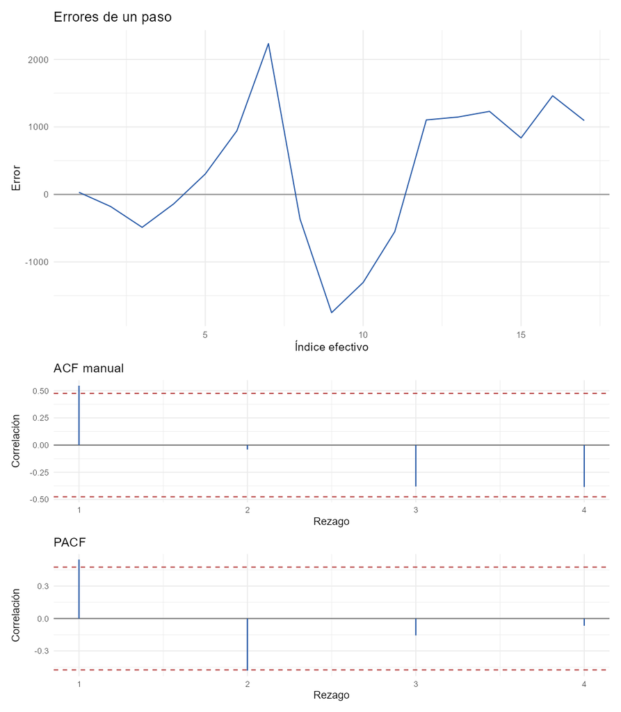

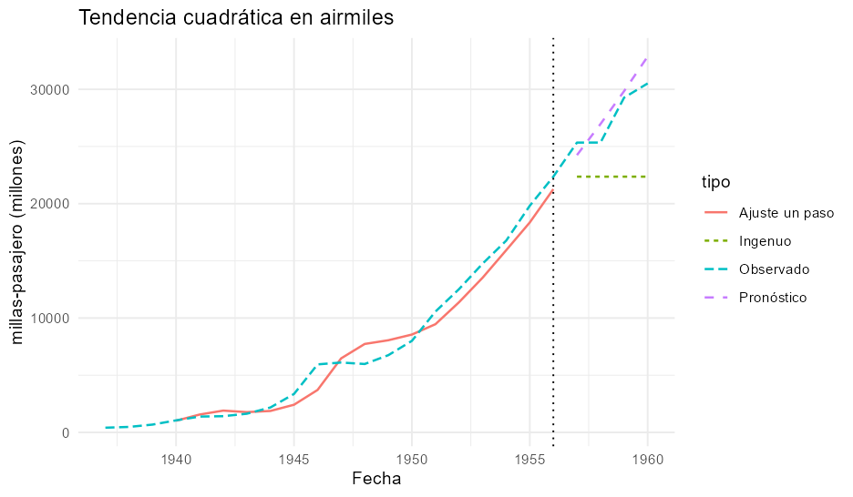

### 4.6.5 Conclusión y recomendación

```r
cierre_md(x)
```

**Conclusión.** Se ajustó Tendencia cuadrática con cuadratica; R2=0.989. En las 4 observaciones de validación obtuvo MSE = 2416497.737, MAD = 1408.887, MAPE = 5.092 y MASE = 1.205. El referente ingenuo produjo MASE = 4.496. En los errores, Ljung–Box dio p = 3.01e-04 y la prueba de media cero dio p = 0.2146.

**Recomendación.** El resultado podría servir a un planificador del transporte aéreo interesado en crecimiento acelerado solamente hasta un horizonte de 4 años. Su límite principal es que la parábola puede crecer sin límite fuera del rango observado; esto se evidencia con MASE = 1.205 y p de Ljung–Box residual = 3.01e-04.

## 4.7 Tendencia exponencial sobre `JohnsonJohnson`

### 4.7.1 Serie y patrón antes del ajuste

```r
x <- resultados[[7]]
mostrar_serie(x)
```

| Campo | Valor |
| --- | --- |
| Objeto de R | JohnsonJohnson |
| Fuente documentada en help() | Shumway y Stoffer (2000), Time Series Analysis and its Applications, ejemplo 1.1. |
| Unidad | ganancias trimestrales por acción (USD) |
| Frecuencia | 4 |
| Rango | 1960-01-01 a 1980-10-01 |
| Observaciones | 84 |

**Contrastes individuales de la ACF.** Bajo H0: ρ_h = 0, se compara cada r_h con la banda ±0.231. Quedan fuera de la banda: h=1 (r=0.941); h=2 (r=0.883); h=3 (r=0.842); h=4 (r=0.808); h=5 (r=0.762); h=6 (r=0.717); h=7 (r=0.678); h=8 (r=0.647); h=9 (r=0.605); h=10 (r=0.558); h=11 (r=0.519); h=12 (r=0.485); h=13 (r=0.442); h=14 (r=0.397); h=15 (r=0.364); h=16 (r=0.332); h=17 (r=0.290); h=18 (r=0.240). Estos contrastes son descriptivos e individuales; no sustituyen la prueba conjunta de Ljung–Box.

**Lectura previa del patrón.** El nivel crece aproximadamente de forma multiplicativa, pero existe una oscilación trimestral fuerte. La tendencia exponencial representa el crecimiento, no la estacionalidad; esta omisión debe aparecer como límite del ejemplo.

#### 4.7.1.1 Ljung–Box sobre la serie

1. **Hipótesis:**

$$\begin{aligned}
H_0 &: \rho_1 = \rho_2 = \cdots = \rho_m = 0, \\
H_1 &: \exists\,h \in \{1,\ldots,m\}: \rho_h \neq 0.
\end{aligned}$$

2. **Estadístico y distribución bajo H₀:**

$$\begin{aligned}
Q_m &= T(T+2) \sum_{h=1}^{m} \frac{r_h^2}{T-h}, \\[4pt]
Q_m \mid H_0 &\approx \chi^2_{18}.
\end{aligned}$$

3. **Región de rechazo con α = 0.05:**

$$Q_m > \chi^2_{0.95;18} = 28.8693$$

4. **Valor observado y valor p:**

$$Q_{m,\mathrm{obs}} = 562.8694, \qquad p = 5.98 \times 10^{-108}$$

5. **Decisión:** Se rechaza H0 al nivel del 5 %.
6. **Lectura en contexto:** La serie no se comporta como ruido blanco: existe dependencia conjunta antes de ajustar el método.

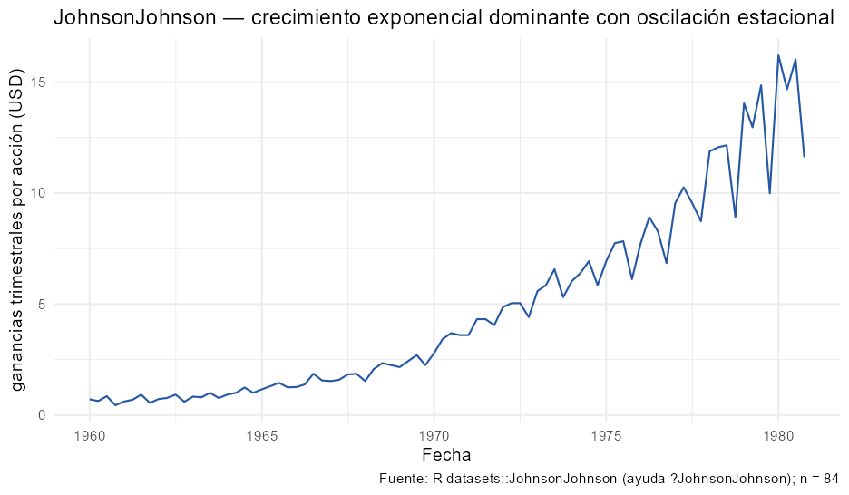

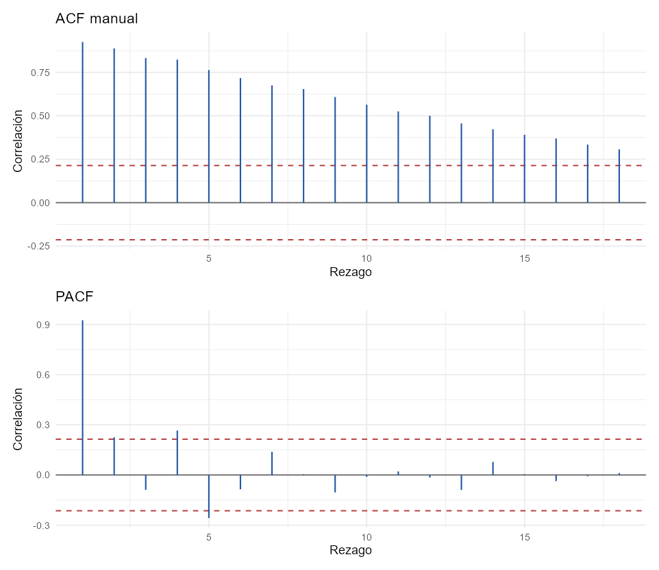

La tendencia se estima sobre $\log(Y_t)$ y vuelve a la escala original con la corrección $\exp(\widehat{\sigma}_{\log}^2/2)$. La serie, sin embargo, tiene oscilación trimestral; por ello este ejemplo solo puede mantenerse si se argumenta que el objetivo es aislar el crecimiento y se reconoce que el modelo no es estacional.

### 4.7.2 Ajuste, coeficientes y validación

```r
mostrar_ajuste(x)
```

El tramo de estimación contiene **72 observaciones** y la validación conserva las últimas **12 observaciones**. El ajuste seleccionado es **exponencial; R2=0.973**.

Este método no requiere seleccionar parámetros mediante una rejilla; sus parámetros se estiman directamente con el tramo de estimación.

| Muestra | MSE | MAD | MAPE | MASE |
| --- | --- | --- | --- | --- |
| Estimación: pronóstico de un paso | 0.4295 | 0.4050 | 13.9261 | 0.7715 |
| Validación: método | 8.3287 | 1.8826 | 16.9187 | 3.5860 |
| Validación: Ingenuo estacional | 15.5810 | 3.4275 | 24.6506 | 6.5286 |

Con el mismo origen y horizonte, el método sí supera al referente según MASE: 3.586 frente a 6.529.

```r
mostrar_coeficientes(x)
```

### 4.7.3 Coeficientes y contrastes robustos

| Término | Estimación | SE ordinario | SE HAC | t HAC | p HAC |
| --- | --- | --- | --- | --- | --- |
| intercepto | -0.69684 | 0.03597 | 0.04258 | -16.36631 | 1.26e-25 |
| t | 0.04277 | 8.56e-04 | 9.96e-04 | 42.96160 | 4.82e-52 |

#### 4.7.3.1 Coeficiente intercepto con error HAC

1. **Hipótesis:**

$$\begin{aligned}
H_0 &: \beta_{0} = 0, \\
H_1 &: \beta_{0} \neq 0.
\end{aligned}$$

2. **Estadístico y distribución bajo H₀:**

$$\begin{aligned}
t_{\mathrm{HAC}} &= \frac{\widehat{\beta}_{0}}{\operatorname{SE}_{\mathrm{HAC}}(\widehat{\beta}_{0})}, \\[4pt]
t_{\mathrm{HAC}} \mid H_0 &\sim t_{70}.
\end{aligned}$$

3. **Región de rechazo con α = 0.05:**

$$|t_{\mathrm{HAC}}| > t_{0.975;70} = 1.9944$$

4. **Valor observado y valor p:**

$$t_{\mathrm{HAC,obs}} = -16.3663, \qquad p = 1.26 \times 10^{-25}$$

5. **Decisión:** Se rechaza H0 al nivel del 5 %.
6. **Lectura en contexto:** Hay evidencia robusta de que el coeficiente intercepto contribuye a la tendencia.

#### 4.7.3.2 Coeficiente t con error HAC

1. **Hipótesis:**

$$\begin{aligned}
H_0 &: \beta_{1} = 0, \\
H_1 &: \beta_{1} \neq 0.
\end{aligned}$$

2. **Estadístico y distribución bajo H₀:**

$$\begin{aligned}
t_{\mathrm{HAC}} &= \frac{\widehat{\beta}_{1}}{\operatorname{SE}_{\mathrm{HAC}}(\widehat{\beta}_{1})}, \\[4pt]
t_{\mathrm{HAC}} \mid H_0 &\sim t_{70}.
\end{aligned}$$

3. **Región de rechazo con α = 0.05:**

$$|t_{\mathrm{HAC}}| > t_{0.975;70} = 1.9944$$

4. **Valor observado y valor p:**

$$t_{\mathrm{HAC,obs}} = 42.9616, \qquad p = 4.82 \times 10^{-52}$$

5. **Decisión:** Se rechaza H0 al nivel del 5 %.
6. **Lectura en contexto:** Hay evidencia robusta de que el coeficiente t contribuye a la tendencia.

### 4.7.4 Supuestos y validación de los errores

```r
mostrar_diagnosticos(x)
```

Los diagnósticos utilizan **70 errores efectivos** después de retirar las posiciones de calentamiento.

#### 4.7.4.1 Media cero de los errores

1. **Hipótesis:**

$$\begin{aligned}
H_0 &: \mu_e = 0, \\
H_1 &: \mu_e \neq 0.
\end{aligned}$$

2. **Estadístico y distribución bajo H₀:**

$$\begin{aligned}
t &= \frac{\bar e}{s_e/\sqrt{n_e}}, \\[4pt]
t \mid H_0 &\sim t_{69}.
\end{aligned}$$

3. **Región de rechazo con α = 0.05:**

$$|t| > t_{0.975;69} = 1.9949$$

4. **Valor observado y valor p:**

$$t_{\mathrm{obs}} = -0.0929, \qquad p = 0.9262$$

5. **Decisión:** No se rechaza H0 al nivel del 5 %.
6. **Lectura en contexto:** No se detecta sesgo medio en los errores al 5 %.

#### 4.7.4.2 Ljung–Box sobre los errores

1. **Hipótesis:**

$$\begin{aligned}
H_0 &: \rho_1 = \rho_2 = \cdots = \rho_m = 0, \\
H_1 &: \exists\,h \in \{1,\ldots,m\}: \rho_h \neq 0.
\end{aligned}$$

2. **Estadístico y distribución bajo H₀:**

$$\begin{aligned}
Q_m &= T_e(T_e+2) \sum_{h=1}^{m} \frac{r_h^2}{T_e-h}, \\[4pt]
Q_m \mid H_0 &\approx \chi^2_{m-p} = \chi^2_{15}.
\end{aligned}$$

3. **Región de rechazo con α = 0.05:**

$$Q_m > \chi^2_{0.95;15} = 24.9958$$

4. **Valor observado y valor p:**

$$Q_{m,\mathrm{obs}} = 102.1380, \qquad p = 5.12 \times 10^{-15}$$

5. **Decisión:** Se rechaza H0 al nivel del 5 %.
6. **Lectura en contexto:** Permanece autocorrelación aprovechable: el método no extrajo toda la estructura temporal.

#### 4.7.4.3 Jarque–Bera

1. **Hipótesis:**

$$\begin{aligned}
H_0 &: A = 0 \text{ y } K = 3, \\
H_1 &: A \neq 0 \text{ o } K \neq 3.
\end{aligned}$$

2. **Estadístico y distribución bajo H₀:**

$$\begin{aligned}
JB &= \frac{n}{6}\left[A^2 + \frac{(K-3)^2}{4}\right], \\[4pt]
JB \mid H_0 &\approx \chi^2_2.
\end{aligned}$$

3. **Región de rechazo con α = 0.05:**

$$JB > \chi^2_{0.95;2} = 5.9915$$

4. **Valor observado y valor p:**

$$JB_{\mathrm{obs}} = 152.3793, \qquad p = 8.15 \times 10^{-34}$$

5. **Decisión:** Se rechaza H0 al nivel del 5 %.
6. **Lectura en contexto:** Los errores no son compatibles con normalidad aproximada según asimetría y curtosis.

#### 4.7.4.4 Durbin–Watson

1. **Hipótesis:**

$$\begin{aligned}
H_0 &: \rho_1 = 0, \\
H_1 &: \rho_1 > 0.
\end{aligned}$$

2. **Estadístico y distribución bajo H₀:**

$$\begin{aligned}
d &= \frac{\sum_{t=2}^{n_e}(e_t-e_{t-1})^2}{\sum_{t=1}^{n_e}e_t^2}, \\[4pt]
d \mid H_0 &\sim \textstyle\sum_i \lambda_i Z_i \big/ \sum_i Z_i,\ Z_i \overset{iid}{\sim} \chi^2_1.
\end{aligned}$$

3. **Región de rechazo con α = 0.05 (valor p exacto, método de Imhof 1961, en vez de las cotas $d_L$/$d_U$ tabuladas):**

$$p = P(d \le d_{\mathrm{obs}} \mid H_0) < 0.05 \;\Rightarrow\; \text{rechazar } H_0$$

4. **Valor observado y valor p:**

$$d_{\mathrm{obs}} = 1.0928, \qquad p = 1.59 \times 10^{-5}$$

5. **Decisión:** Se rechaza H0 al nivel del 5 %.
6. **Lectura en contexto:** Hay evidencia de autocorrelación positiva de primer orden en los errores; los valores p ordinarios de los coeficientes no son interpretables y la decisión se apoya en el error estándar HAC.

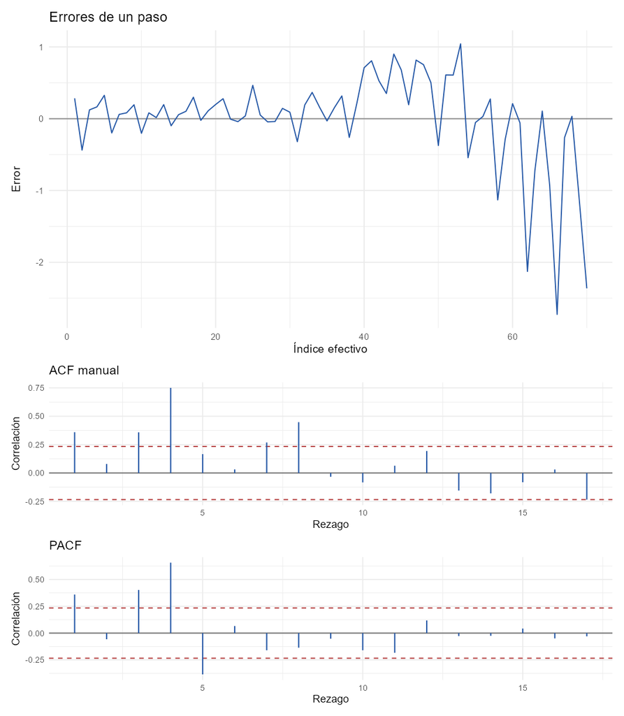

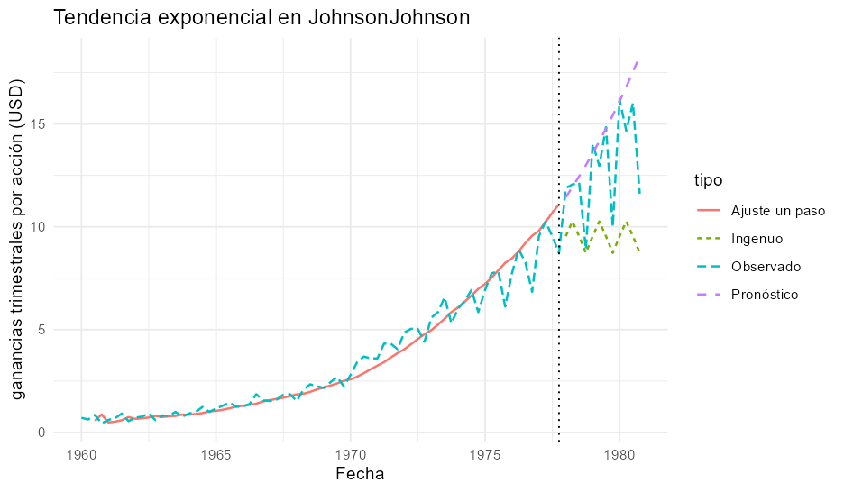

### 4.7.5 Conclusión y recomendación

```r
cierre_md(x)
```

**Conclusión.** Se ajustó Tendencia exponencial con exponencial; R2=0.973. En las 12 observaciones de validación obtuvo MSE = 8.329, MAD = 1.883, MAPE = 16.919 y MASE = 3.586. El referente ingenuo estacional produjo MASE = 6.529. En los errores, Ljung–Box dio p = 5.12e-15 y la prueba de media cero dio p = 0.9262.

**Recomendación.** El resultado podría servir a un analista de ganancias empresariales solamente hasta un horizonte de 12 trimestres. Su límite principal es que la tendencia exponencial omite la estacionalidad trimestral; esto se evidencia con MASE = 3.586 y p de Ljung–Box residual = 5.12e-15.